Coding Essentials for Astronomers

# SciPy: Optimization and Curve Fitting

## Introduction

In Lecture 17, you learned to work with uncertain measurements using scipy.stats. You discovered how real astronomical observations scatter around true values due to measurement errors, and you learned sophisticated techniques to handle this uncertainty. You learned to combine multiple measurements using weighted averaging, to identify and remove outliers using sigma clipping, and to validate your assumptions using Q-Q plots. Throughout that lecture, you were quantifying uncertainty - answering questions like "how confident are we in this measurement?" and "how do we best combine noisy data?"

But there was a deeper insight lurking beneath the surface. When you calculated the mean of your measurements, you weren't just following a statistical recipe - you were actually solving an optimization problem. The mean is special because it's the value that minimizes the sum of squared differences from all your data points. If you tried any other value, the total squared error would be larger. This connection between statistics and optimization is profound, and it opens the door to solving far more complex problems.

Consider what you did in Lecture 17: you had multiple measurements of a single quantity (like a star's brightness), and you found the single best value to represent all those measurements. But what if your problem is more complex? What if you observe a star's brightness changing over time in a periodic pattern, and you need to determine not just one number, but multiple parameters - the average brightness, the amplitude of variation, and the period? What if you observe a star moving across the sky, and you need to find both its position and velocity? What if you see two stars orbiting each other, and you need to determine their masses, orbital period, and the shape of their orbit?

These are **curve fitting** problems, and they're everywhere in astronomy. We rarely measure the quantities we actually want to know directly. We can't put a star on a scale to measure its mass, or stick a thermometer in it to measure its temperature. Instead, we observe things we can measure - positions, velocities, brightnesses, colors - and then we find the physical model parameters that best explain those observations. When a star's position shifts over many years, we fit an orbit to determine the masses. When a star's brightness varies periodically, we fit a curve to determine its pulsation period or rotation rate. When spectral lines shift back and forth in wavelength, we fit a velocity curve to reveal an unseen companion star.

This is where **scipy.optimize** becomes essential. While scipy.stats helped you understand and quantify uncertainty in your measurements, scipy.optimize helps you extract physical meaning from those measurements. It provides the mathematical machinery to find the parameters that make theoretical models match your observations. It's the bridge between messy, noisy data points and clean physical understanding.

In this lecture, you'll learn how to approach optimization problems systematically. You'll understand what it means to search for the "best" parameters, how algorithms navigate complex parameter spaces to find optimal solutions, and how to fit curves to data while properly accounting for measurement uncertainties. Most importantly, you'll see how these mathematical techniques reveal physical reality - turning scattered observations into measurements of fundamental quantities like masses, distances, and orbital parameters.

We'll build these concepts gradually through concrete astronomical examples. We'll start simple - finding a single parameter like a star's brightness - and progressively work up to complex problems like determining the orbital parameters of a binary star system from velocity measurements. By the end, you'll have the tools to extract quantitative physical information from real observational data.

Let's begin by importing the libraries we'll need:

```python
# Import libraries for numerical computing and plotting
import numpy as np
import matplotlib.pyplot as plt

# Import scipy's optimization module for curve fitting
from scipy import optimize

# Import scipy's statistics module for distributions
from scipy import stats
```

Now let's configure our plotting settings. We'll use a larger figure size so our plots are easy to read, increase the font size for clarity, and enable grids to make it easier to read values from the plots:

```python
# Configure default plot settings for clarity and consistency
plt.rcParams['figure.figsize'] = (12, 8)
plt.rcParams['font.size'] = 12
plt.rcParams['lines.linewidth'] = 2
plt.rcParams['axes.grid'] = True
plt.rcParams['grid.alpha'] = 0.3
```

Finally, let's set a random seed to ensure reproducibility. Throughout this lecture, we'll create synthetic observations by adding random noise to known true values. Setting the seed means you'll get exactly the same random numbers every time you run this notebook, making it easier to compare your results with the examples shown here:

```python
# Set random seed for reproducibility
np.random.seed(42)
```

## From Statistics to Optimization: The Conceptual Bridge

Let's start by making the connection between statistics and optimization explicit. In Lecture 17, you learned to calculate both simple means and weighted averages of measurements. When all measurements have equal uncertainty, the simple mean is optimal. When measurements have different uncertainties, the weighted average gives more influence to precise measurements. But what you might not have realized is that both of these are actually solving optimization problems - finding values that minimize specific mathematical functions. To see this clearly, let's create a concrete example.

Imagine you're observing a star's brightness over multiple nights. Each night, you measure the star's **magnitude** - the astronomical brightness scale where smaller numbers mean brighter objects. A star visible to the naked eye might have magnitude 5 or 6, while our Sun has magnitude -26.7 (very bright, hence very negative). The star you're observing has magnitude around 10.5, requiring a small telescope or binoculars to see.

Each measurement you make is slightly different because of random noise. Earth's atmosphere is constantly churning and moving, which causes the star's light to shimmer and vary slightly (this is why stars twinkle). Your detector - a digital camera chip called a CCD (charge-coupled device) - has small random variations in sensitivity. Light pollution from nearby cities adds random background light. All these effects combine to make each measurement slightly different from the star's true brightness.

Let's create synthetic observations to explore this. We'll start by defining three key parameters: the star's true brightness (which we're pretending we don't know), the number of observations we'll make, and the typical measurement uncertainty. These constants will set up our simulation scenario:

```python
# Define the star's true properties
true_brightness = 10.5  # True magnitude (the value we're trying to find)
n_observations = 50      # Number of nights we observed the star
measurement_error = 0.2  # Typical measurement uncertainty in magnitudes
```

The measurement error of 0.2 magnitudes is realistic for amateur observations or small telescopes. Professional telescopes can achieve much smaller errors (0.01 magnitudes or less), but for this example, we'll use a value that makes the noise clearly visible.

Now let's generate our synthetic observations. We'll add random noise drawn from a Gaussian distribution with standard deviation equal to our measurement error. The code below uses `np.random.normal()` with `loc=0` (mean of zero) and `scale=measurement_error` (standard deviation) to generate random noise values, then adds these to the true brightness to simulate realistic observations:

```python
# Generate noisy observations by adding random noise to the true brightness
noise = np.random.normal(loc=0, scale=measurement_error, size=n_observations)
observations = true_brightness + noise

# Display some sample observations
print(f"True brightness: {true_brightness:.2f} magnitudes")
print(f"Measurement uncertainty: {measurement_error:.2f} magnitudes")
print(f"Number of observations: {n_observations}")
print(f"\nFirst 10 observations:")
for i in range(10):
    print(f"  Night {i+1:2d}: {observations[i]:.3f} mag")
```

```
True brightness: 10.50 magnitudes
Measurement uncertainty: 0.20 magnitudes
Number of observations: 50

First 10 observations:
  Night  1: 10.599 mag
  Night  2: 10.472 mag
  Night  3: 10.630 mag
  Night  4: 10.805 mag
  Night  5: 10.453 mag
  Night  6: 10.453 mag
  Night  7: 10.816 mag
  Night  8: 10.653 mag
  Night  9: 10.406 mag
  Night 10: 10.609 mag
```

Notice how each measurement differs from the true value of 10.5 magnitudes. Some are higher, some are lower, but they scatter around the true value. This is exactly what real astronomical measurements look like - the true value plus random noise.

Let's visualize all our observations to see the pattern more clearly. We'll create two plots side by side: one showing the measurements over time, and one showing their distribution as a histogram. In the left plot, we'll use `plt.scatter` to plot each observation and add horizontal lines showing both the true brightness and the mean of our observations. In the right plot, we'll create a histogram with 15 bins to show how the measurements are distributed around the true value. This visualization helps us see both the temporal scatter and the statistical distribution of the noise:

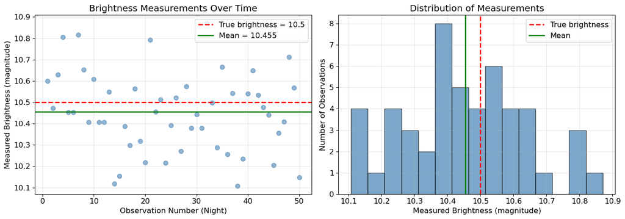

```python
# Create two subplots to visualize the data
fig, (ax1, ax2) = plt.subplots(1, 2, figsize=(14, 5))

# Left plot: measurements vs observation number (time series)
nights = np.arange(1, n_observations + 1)
ax1.scatter(nights, observations, alpha=0.6, s=50, color='steelblue')
ax1.axhline(true_brightness, color='red', linestyle='--', linewidth=2,
            label=f'True brightness = {true_brightness}')
ax1.axhline(np.mean(observations), color='green', linestyle='-', linewidth=2,
            label=f'Mean = {np.mean(observations):.3f}')
ax1.set_xlabel('Observation Number (Night)')
ax1.set_ylabel('Measured Brightness (magnitude)')
ax1.set_title('Brightness Measurements Over Time')
ax1.legend()
ax1.grid(True, alpha=0.3)

# Right plot: histogram showing the distribution of measurements
ax2.hist(observations, bins=15, edgecolor='black', alpha=0.7, color='steelblue')
ax2.axvline(true_brightness, color='red', linestyle='--', linewidth=2,
            label='True brightness')
ax2.axvline(np.mean(observations), color='green', linestyle='-', linewidth=2,
            label='Mean')
ax2.set_xlabel('Measured Brightness (magnitude)')
ax2.set_ylabel('Number of Observations')
ax2.set_title('Distribution of Measurements')
ax2.legend()
ax2.grid(True, alpha=0.3)

plt.tight_layout()
plt.show()
```

The left plot shows that the measurements scatter randomly around the true value with no systematic trend over time - the variations are purely random. The right plot shows that the measurements form a bell-shaped distribution centered near the true value, which is exactly what we expect from Gaussian noise. The green line shows the mean of our observations, which is close to (but not exactly equal to) the true value.

In Lecture 17, you learned that the mean is calculated using the formula:

$$\bar{x} = \frac{1}{n}\sum_{i=1}^n x_i$$

You simply sum all measurements and divide by the count. You also learned about weighted averaging, where measurements with smaller uncertainties (higher precision) contribute more to the average than measurements with larger uncertainties. But here's the deeper insight: the mean (and weighted mean) is special not because of these formulas, but because of what it optimizes. The mean is the value that minimizes the **sum of squared errors**. Let's explore what this means.

## The Cost Function: Quantifying How Wrong We Are

Instead of just calculating the mean, let's think about the problem differently. Suppose we want to find the best estimate of the star's true brightness. We'll frame this as a search problem: we'll try different possible brightness values (let's call them "guesses"), and for each guess, we'll quantify how well it agrees with our observations.

To quantify agreement, we need a **cost function** (also called an **objective function** or **loss function**). This is a mathematical function that takes a parameter guess as input and returns a single number indicating how "wrong" that guess is. The lower the cost, the better the guess. Our goal is to find the parameter value that minimizes this cost.

For our brightness estimation problem, let's use the **chi-squared** ($\chi^2$) cost function, which is fundamental in astronomy and statistics. Here's the logic behind this choice. For each observation, we can calculate the **residual** - the difference between what we observed and what our guess predicts:

$$\text{residual}_i = \text{observation}_i - \text{guess}$$

If we guess 10.3 but observed 10.5, the residual is +0.2. If we guess 10.7 but observed 10.5, the residual is -0.2. Residuals can be positive or negative, but we want to penalize errors in both directions equally. We also want larger errors to be penalized more heavily than small errors.

In real astronomy, we must account for measurement uncertainties. An observation with small uncertainty (high precision) should have more influence on our fit than an observation with large uncertainty (low precision). This is exactly the concept of **weighted averaging** from Lecture 17! We do this by dividing each residual by its measurement uncertainty $\sigma_i$ before squaring. This gives us the chi-squared statistic:

$$\chi^2(\text{guess}) = \sum_{i=1}^n \left(\frac{\text{observation}_i - \text{guess}}{\sigma_i}\right)^2$$

Notice the $\sigma_i$ in the denominator - this is what provides the weighting. When $\sigma_i$ is small (precise measurement), that term contributes more to $\chi^2$. When $\sigma_i$ is large (imprecise measurement), that term contributes less. This is the optimization equivalent of the weighted mean you learned in Lecture 17.

In our current example, all measurements have the same uncertainty ($\sigma_i = \sigma$ = 0.2 mag for all observations). When errors are equal like this, the $\sigma$ term becomes a constant that doesn't affect where the minimum occurs - so the weighted mean reduces to the simple mean. But we'll include the $\sigma$ in our calculations from the start because in real astronomy, different observations almost always have different uncertainties, and the weighting is crucial.

Now let's implement the chi-squared cost function as a Python function. This function will take a brightness guess as input, calculate the residuals (differences between observations and the guess), divide each by the measurement error (to properly weight by uncertainty), square them, sum them up, and return the total chi-squared value. The lower the returned value, the better the guess matches our data:

```python
def brightness_cost(brightness_guess):
    """
    Calculate chi-squared for a brightness estimate.

    This function quantifies how well a proposed brightness value
    agrees with all our observations, properly accounting for
    measurement uncertainties.

    Parameters:
    -----------
    brightness_guess : float
        The proposed brightness value in magnitudes

    Returns:
    --------
    float
        The chi-squared value (lower is better)
    """
    # Calculate the difference between each observation and our guess
    residuals = observations - brightness_guess

    # Calculate chi-squared: sum of squared residuals weighted by uncertainties
    # Dividing by measurement_error gives more weight to precise observations
    # In this example, all errors are equal (0.2 mag), so all observations
    # have equal weight - but we include sigma to show the proper form
    chi_squared = np.sum((residuals / measurement_error)**2)

    return chi_squared
```

This function is the heart of our optimization problem. It takes any brightness guess and tells us how good that guess is by calculating chi-squared. The division by `measurement_error` weights each observation by its precision - just like the weighted averages in Lecture 17.

Lower $\chi^2$ means better agreement between our model and the observations. Now let's test this function with several different guesses to see how it behaves. We'll evaluate the cost function at five different brightness values ranging from 10.0 to 11.0 magnitudes. By computing and printing the cost for each guess, we can see which value produces the lowest cost and thus best agrees with our observations:

```python
# Test the cost function with different brightness guesses
test_guesses = [10.0, 10.3, 10.5, 10.7, 11.0]

print("Testing the cost function with different brightness guesses:")
print("=" * 50)

# The < and > symbols control text alignment in f-string formatting:
# <25 means left-align within 25 characters
# >15 means right-align within 15 characters
print(f"{'Brightness Guess (mag)':<25} {'Total Cost':>15}")
print("=" * 50)

for guess in test_guesses:
    cost = brightness_cost(guess)
    print(f"  {guess:5.1f}                        {cost:12.3f}")

print("=" * 50)
```

```
Testing the cost function with different brightness guesses:
==================================================
Brightness Guess (mag)         Total Cost
==================================================
   10.0                             301.389
   10.3                              72.710
   10.5                              45.257
   10.7                             117.804
   11.0                             414.126
==================================================
```

Look at the pattern in the results. When our guess is far from the true value (like 10.0 or 11.0), the cost is high - these guesses don't match our observations well. When our guess is close to the true value (like 10.5), the cost is lower. The cost function is doing exactly what we want: it assigns high penalties to bad guesses and low penalties to good guesses.

Now here's a crucial question: which guess gives us the minimum cost? We tested five specific values, but there are infinitely many possible brightness values we could try. To visualize the complete picture, let's evaluate the cost at many brightness values across a range and plot it:

```python
# Create a fine grid of possible brightness values
brightness_grid = np.linspace(9.5, 11.5, 500)

# Calculate the cost at each point on the grid
costs = np.array([brightness_cost(b) for b in brightness_grid])
```

We're evaluating our cost function at 500 equally-spaced brightness values between 9.5 and 11.5 magnitudes. We use a list comprehension `[brightness_cost(b) for b in brightness_grid]` to evaluate the cost at each point, then convert to a NumPy array. This gives us a complete picture of the **optimization landscape** - how cost varies across all possible brightness values.

Now let's visualize this landscape and find the minimum. We'll create a plot showing the cost function as a blue curve, mark the minimum point we found, and highlight the true brightness value for comparison. We'll use `np.argmin()` to find the index of the minimum cost, then extract the corresponding brightness value:

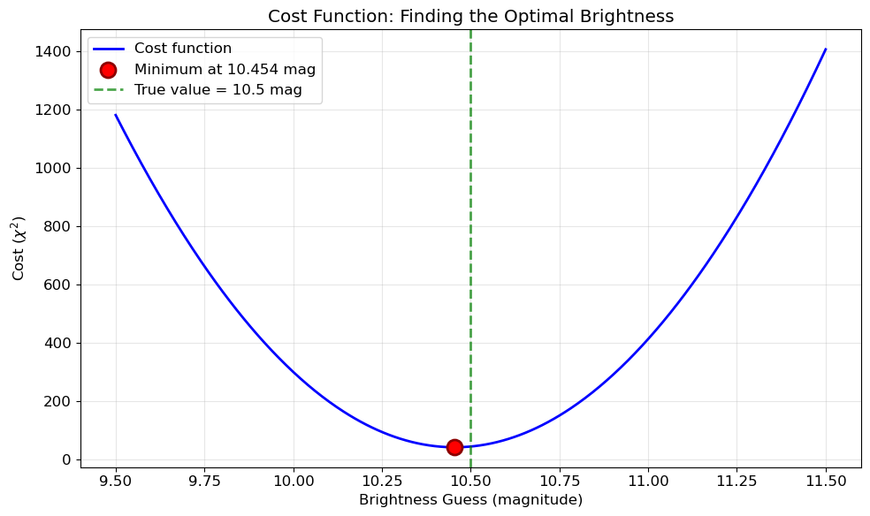

```
Minimum cost found at brightness = 10.4539 mag
For comparison, mean of observations = 10.4549 mag
```

```python
# Plot the cost function
plt.figure(figsize=(10, 6))

# Plot cost vs brightness
plt.plot(brightness_grid, costs, 'b-', linewidth=2, label='Cost function')

# Mark the minimum we can find from our grid
min_index = np.argmin(costs)
optimal_brightness = brightness_grid[min_index]
min_cost = costs[min_index]

plt.scatter(optimal_brightness, min_cost, color='red', s=150, zorder=5,
           marker='o', edgecolors='darkred', linewidth=2,
           label=f'Minimum at {optimal_brightness:.3f} mag')

# Mark the true brightness for reference
plt.axvline(true_brightness, color='green', linestyle='--', alpha=0.7,
           linewidth=2, label=f'True value = {true_brightness} mag')

plt.xlabel('Brightness Guess (magnitude)')
plt.ylabel('Cost ($\chi^2$)')
plt.title('Cost Function: Finding the Optimal Brightness')
plt.legend()
plt.grid(True, alpha=0.3)
plt.tight_layout()
plt.show()

print(f"\nMinimum cost found at brightness = {optimal_brightness:.4f} mag")
print(f"For comparison, mean of observations = {np.mean(observations):.4f} mag")
```

This plot reveals the structure of our optimization problem. The cost function has a smooth, parabolic shape with a single minimum - this is called a **convex** problem. No matter where you start searching, you can follow the downhill gradient to find this unique minimum. The red dot shows where the minimum occurs, which is essentially identical to the mean of our observations.

This is not a coincidence! Although we won't prove it here, minimizing the chi-squared cost function mathematically leads to exactly the formulas you learned in Lecture 17:

- When all measurement errors are equal ($\sigma_i = \sigma$), minimizing $\chi^2$ gives you the **simple average**: $\bar{x} = \frac{1}{n}\sum_i x_i$
- When measurement errors differ, minimizing $\chi^2$ gives you the **weighted average**: $\bar{x} = \frac{\sum_i w_i x_i}{\sum_i w_i}$ where $w_i = 1/\sigma_i^2$

So the statistical formulas from Lecture 17 and optimization are two different paths to the same answer! The formulas give you the answer directly, while optimization searches for it by minimizing cost. For simple problems like estimating a mean, the formula is faster. But for complex problems with many parameters and non-linear relationships, optimization is the only practical approach.

We found the minimum by evaluating the cost at 500 points and picking the smallest. This works, but it's inefficient - we had to make 500 function calls! The 500 comes from our grid search above where we created `brightness_grid = np.linspace(9.5, 11.5, 500)` - we evaluated the cost function at 500 equally-spaced brightness values. And this brute-force approach becomes completely impractical for problems with multiple parameters. A problem with just 10 parameters would require 500^10 evaluations at the same grid density - that's an astronomically large number of function calls!

This is where automated optimization becomes essential. We need smart algorithms that can find the minimum efficiently without exhaustive search.

## Using scipy.optimize for Simple Problems

The **scipy.optimize** module provides sophisticated algorithms that find minima efficiently without exhaustive search. These algorithms use clever strategies: they evaluate the function at carefully chosen points, use the information to predict where the minimum likely lies, move in that direction, and repeat until convergence. Instead of 500 function calls, these algorithms typically need only dozens to find the minimum!

The `scipy.optimize` module contains many different optimization functions, each designed for different types of problems:

- **minimize_scalar**: For one-dimensional problems (one parameter to optimize)
- **minimize**: For multi-dimensional problems (multiple parameters)
- **curve_fit**: Specifically designed for fitting curves to data
- **root**: For finding zeros of functions (where function equals zero)
- **least_squares**: For non-linear least squares problems

Since our brightness estimation problem has just one parameter, we'll use `minimize_scalar`. This function implements algorithms specifically designed for one-dimensional optimization.

### Understanding minimize_scalar

The `minimize_scalar` function requires just one mandatory argument: the function to minimize. It should take a single number as input and return a single number (the cost) as output.

The function uses a sophisticated algorithm (Brent's method by default) that combines parabolic interpolation with golden section search to efficiently find the minimum. Instead of evaluating the function at hundreds of points like our grid search, it strategically chooses where to evaluate next based on what it has learned, typically converging in just a few dozen function calls.

Let's use `minimize_scalar` to find the optimal brightness. We'll import it from `scipy.optimize` and call it with our `brightness_cost` function:

```python
# Import the minimize_scalar function
from scipy.optimize import minimize_scalar

# Use Brent's method to find the minimum (no bounds needed)
result = minimize_scalar(brightness_cost)
```

The function returns an `OptimizeResult` object containing detailed information about what it found. Let's examine this object to see what the algorithm discovered. We'll print several key fields: `success` (whether it converged), `x` (the optimal parameter value), `fun` (the cost at that point), and `nfev` (number of function evaluations):

```python
# Display the optimization results
print("Optimization Results (Brent's Method):")
print("=" * 50)
print(f"Success: {result.success}")
print(f"Optimal brightness: {result.x:.6f} mag")
print(f"Minimum cost: {result.fun:.6f}")
print(f"Number of function evaluations: {result.nfev}")
print(f"Number of iterations: {result.nit}")
print("\nFor comparison:")
print(f"Mean of observations: {np.mean(observations):.6f} mag")
print(f"True brightness: {true_brightness:.6f} mag")
```

```
Optimization Results (Brent's Method):
==================================================
Success: True
Optimal brightness: 10.454905 mag
Minimum cost: 42.715132
Number of function evaluations: 9
Number of iterations: 4

For comparison:
Mean of observations: 10.454905 mag
True brightness: 10.500000 mag
```

The `result.success` field tells us whether the algorithm converged successfully. The `result.x` field contains the optimal parameter value (the brightness that minimizes cost). The `result.fun` field contains the function value at that minimum (the minimum cost). The `result.nfev` field tells us how many times the algorithm evaluated our cost function - notice it's far fewer than the 500 evaluations we used earlier!

The optimal brightness found by `minimize_scalar` is essentially identical to the mean we calculated directly. This confirms that optimization and statistics are two sides of the same coin: minimizing squared error gives you the mean.

Now let's try the bounded method, which is useful when you have physical constraints on your parameters. For example, astronomical magnitudes typically range from about -30 (the Sun) to +30 (extremely faint objects), so we might impose reasonable bounds:

```python
# Use bounded method with physically reasonable limits
result_bounded = minimize_scalar(
    brightness_cost,
    bounds=(8.0, 13.0),  # Reasonable range for this type of star
    method='bounded'
)

print("Optimization Results (Bounded Method):")
print("=" * 50)
print(f"Success: {result_bounded.success}")
print(f"Optimal brightness: {result_bounded.x:.6f} mag")
print(f"Minimum cost: {result_bounded.fun:.6f}")
print(f"Number of function evaluations: {result_bounded.nfev}")
```

```
Optimization Results (Bounded Method):
==================================================
Success: True
Optimal brightness: 10.454905 mag
Minimum cost: 42.715132
Number of function evaluations: 6
```

The bounded method finds the same answer (since the true minimum lies well within our bounds), but it uses a different search strategy. Bounded optimization is essential when your parameters have physical constraints - for example, a distance can't be negative, a probability must be between 0 and 1, or a temperature must be above absolute zero.

Notice that `minimize_scalar` found the minimum with only about 10 function evaluations, compared to the 500 evaluations we used in our brute-force grid search. This efficiency becomes crucial for complex problems!

## From One Parameter to Many: Introduction to Curve Fitting

Finding the optimal value of a single parameter is useful, but astronomy rarely involves just one parameter. More often, we observe data that varies with time or wavelength or position, and we need to fit a model with multiple parameters. This is called **curve fitting** or **regression**.

Here's a concrete example. Imagine you're observing a star moving across the sky. Stars aren't fixed - they have **proper motion**, slowly drifting relative to distant background galaxies due to their motion through space. Modern telescopes like Gaia can measure positions with incredible precision - down to milliarcseconds, which are thousandths of an arcsecond. For context, one arcsecond is 1/3600 of a degree. A human hair held at arm's length subtends about 1/30 of an arcsecond, so a milliarcsecond is about 30 times smaller than that! While Gaia's spatial resolution is at the milliarcsecond level, its photocenter measurements (the center of light from a star) can achieve even better precision - down to tens of microarcseconds for bright stars.

As a star moves, its position changes linearly with time:

$$\text{position}(t) = \text{position}_0 + \text{velocity} \times t$$

This equation has two parameters: the initial position (where the star was at time zero) and its velocity (how fast it's moving). By measuring the star's position at multiple times and fitting this linear model, we can determine both parameters.

```python
# True parameters of the moving star
true_position0 = 100.0  # Initial position in milliarcseconds
true_velocity = 5.0      # Velocity in milliarcseconds per year

# Observation times (in years)
n_obs = 20
observation_times = np.linspace(0, 4, n_obs)  # Observe over 4 years

print(f"Observing a star moving across the sky")
print(f"True initial position: {true_position0} milliarcseconds")
print(f"True velocity: {true_velocity} milliarcseconds/year")
print(f"Observation span: {observation_times[-1]} years")
print(f"Number of observations: {n_obs}")
```

```
Observing a star moving across the sky
True initial position: 100.0 milliarcseconds
True velocity: 5.0 milliarcseconds/year
Observation span: 4.0 years
Number of observations: 20
```

Now let's calculate the true positions at each observation time, then add realistic measurement noise. In real astronomy, different observations typically have different measurement uncertainties - observations made under poor seeing conditions or at low elevation have larger errors.

Let's simulate this realistic scenario. In the code below, we'll create **inhomogeneous errors** - that is, each observation will have its own uncertainty value. We'll use `np.random.uniform()` to generate varying error magnitudes between 1.5 and 3.0 milliarcseconds, then draw noise from a normal distribution with each observation's specific uncertainty using `np.random.normal(0, sigma)` for each error value. This mimics real observational astronomy where measurement quality varies from night to night.

```python
# Calculate the true position at each observation time
true_positions = true_position0 + true_velocity * observation_times

# Generate inhomogeneous measurement errors
# In real astronomy, observation quality varies due to weather, telescope pointing, etc.
# We'll simulate errors ranging from 1.5 to 3.0 milliarcseconds
np.random.seed(43)  # Different seed for errors
position_errors = np.random.uniform(1.5, 3.0, n_obs)

# Add measurement noise according to each observation's uncertainty
noise = np.array([np.random.normal(0, sigma) for sigma in position_errors])
observed_positions = true_positions + noise

# Display some observations with their uncertainties
print("\nSample observations:")
print(f"{'Time (years)':<15} {'Position (mas)':<20} {'Error (mas)':<15} {'True Position (mas)':<20}")
print("=" * 70)
for i in range(5):
    print(f"{observation_times[i]:<15.2f} {observed_positions[i]:<20.2f} {position_errors[i]:<15.2f} {true_positions[i]:<20.2f}")
print("...")
```

```
Sample observations:
Time (years)    Position (mas)       Error (mas)     True Position (mas)
======================================================================
0.00            100.82               1.67            100.00
0.21            100.75               2.41            101.05
0.42            105.40               1.70            102.11
0.63            102.01               1.86            103.16
0.84            102.13               1.99            104.21
...
```

The abbreviation "mas" stands for milliarcseconds. Notice how the observed positions differ from the true positions due to measurement noise, and how the measurement uncertainties vary across observations. Let's visualize these observations to see the motion pattern. We'll also plot the true motion as a line for comparison:

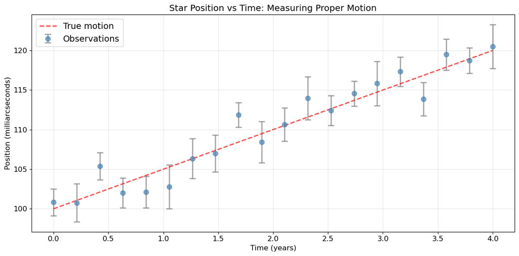

```python
# Plot the observations
plt.figure(figsize=(12, 6))

# Plot observations with error bars (note that error bar sizes vary!)
plt.errorbar(observation_times, observed_positions, yerr=position_errors,
             fmt='o', markersize=8, capsize=5, capthick=2, alpha=0.7,
             color='steelblue', ecolor='gray', label='Observations')

# Plot the true motion for comparison
plt.plot(observation_times, true_positions, 'r--', linewidth=2,
        alpha=0.7, label='True motion')

plt.xlabel('Time (years)')
plt.ylabel('Position (milliarcseconds)')
plt.title('Star Position vs Time: Measuring Proper Motion')
plt.legend(fontsize=14)
plt.grid(True, alpha=0.3)
plt.tight_layout()
plt.show()
```

The observations clearly show a linear trend - the star is moving! But the measurements scatter around the true line due to noise. Notice how the error bars vary in size - some observations have larger uncertainties (longer error bars) than others, just like in real astronomical data. Our goal is to fit a line through these points while properly accounting for these varying uncertainties.

## Fitting Linear Models with curve_fit

To fit this linear model, we need to find the values of position0 and velocity that minimize chi-squared - exactly the same principle we used earlier for estimating brightness, but now with multiple parameters! Just as before, we want to minimize:

$$\chi^2 = \sum_{i=1}^n \left(\frac{\text{observation}_i - \text{model}_i}{\sigma_i}\right)^2$$

where now our model is $\text{model}_i = \text{position}_0 + \text{velocity} \times \text{time}_i$, and each observation has its own uncertainty $\sigma_i$. This is called **weighted least squares** because observations with smaller errors (more weight) have more influence on the fit.

The scipy.optimize module provides a powerful function called `curve_fit` that finds the parameter values that minimize chi-squared for us. We just need to:

1. Define our model as a Python function
2. Provide our observations (x-values and y-values) and their uncertainties
3. Call `curve_fit` to find the best parameters

The `curve_fit` function is remarkably flexible - it can fit any model to data, whether linear or non-linear, with any number of parameters. Let's start by defining our linear motion model:

```python
def linear_model(time, position0, velocity):
    """
    Model for linear stellar motion.

    This function calculates the predicted position of a star
    at any given time, based on its initial position and velocity.

    Parameters:
    -----------
    time : array-like
        Time values in years (this is the independent variable)
    position0 : float
        Initial position in milliarcseconds (parameter to fit)
    velocity : float
        Velocity in milliarcseconds per year (parameter to fit)

    Returns:
    --------
    array
        Predicted positions at each time
    """
    return position0 + velocity * time
```

This function is our physical model. It takes time as input (the independent variable) and two parameters (position0 and velocity), and returns the predicted position. The structure is important: the first argument must be the independent variable, and the remaining arguments are the parameters to fit.

Now let's use `curve_fit` to determine the optimal parameters. The function signature is:

```
popt, pcov = curve_fit(f, xdata, ydata, p0=None, sigma=None, absolute_sigma=False, ...)
```

The key arguments are:

- **f**: Your model function (must take independent variable first, then parameters)
- **xdata**: Your independent variable values (time in our case)
- **ydata**: Your dependent variable values (observed positions)
- **p0**: Optional initial guesses for parameters (helps for non-linear fits)
- **sigma**: Optional measurement uncertainties (for weighted fitting)
- **absolute_sigma**: If True, treats sigma as absolute errors; if False, rescales them

**Important note about uncertainties:** The `sigma` parameter specifies **uncertainties in the y-values only** (the dependent variable, e.g., measured positions or brightnesses). Accounting for uncertainties in the x-values (independent variable, e.g., time measurements) is a much more complex problem that involves **hierarchical Bayesian inference**, which is beyond the scope of this course. In our examples here, x-uncertainties are negligible compared to y-uncertainties, so this approximation is appropriate.

The function returns two things:

- **popt**: Optimal parameter values (the best fit)
- **pcov**: Covariance matrix (tells us about parameter uncertainties and correlations)

Let's fit our data. We'll first import `curve_fit` from `scipy.optimize`, set initial parameter guesses (starting values for the optimization), then call `curve_fit` with our model function, observation data, initial guesses, measurement uncertainties, and specify `absolute_sigma=True` to treat our error values as actual standard deviations rather than relative weights:

```python
# Import curve_fit
from scipy.optimize import curve_fit

# Fit the linear model to our observations
# We provide the measurement uncertainties via sigma - this weights the fit!
popt, pcov = curve_fit(
    linear_model,          # The model function
    observation_times,     # Independent variable (x-values)
    observed_positions,    # Dependent variable (y-values)
    sigma=position_errors, # Measurement uncertainties for each observation
    absolute_sigma=True    # Treat sigma as absolute errors (not relative)
)

# Extract the fitted parameters
fitted_position0, fitted_velocity = popt

print("Linear Fit Results:")
print("=" * 50)
print(f"Fitted initial position: {fitted_position0:.3f} mas")
print(f"Fitted velocity: {fitted_velocity:.3f} mas/year")
print("\nTrue values:")
print(f"True initial position: {true_position0:.3f} mas")
print(f"True velocity: {true_velocity:.3f} mas/year")
```

```
Linear Fit Results:
==================================================
Fitted initial position: 100.635 mas
Fitted velocity: 4.925 mas/year

True values:
True initial position: 100.000 mas
True velocity: 5.000 mas/year
```

The fitted values are very close to the true values! This demonstrates that `curve_fit` successfully recovered the underlying parameters from noisy observations with varying uncertainties.

Excellent! The fitted parameters are very close to the true values. The small differences are due to the random measurement noise - with perfect, noise-free data, we'd recover the true values exactly.

The `curve_fit` function minimized chi-squared: it used an optimization algorithm to find the combination of position0 and velocity values that minimizes the weighted sum of squared residuals. By providing `sigma=position_errors`, we ensured that observations with smaller uncertainties had more influence on the fit - exactly like the weighted averaging in Lecture 17!

Now let's visualize how well our fitted model matches the data. We can use the same `linear_model` function with our fitted parameters to predict positions at any time, and compare these predictions to our observations:

[figure not shown]

```python
# Calculate the fitted model line
fitted_positions = linear_model(observation_times, fitted_position0, fitted_velocity)

# Create a smooth curve for plotting
time_smooth = np.linspace(0, 4, 200)
fitted_curve_smooth = linear_model(time_smooth, fitted_position0, fitted_velocity)

# Create the plot
plt.figure(figsize=(12, 6))

# Plot observations with their varying error bars
plt.errorbar(observation_times, observed_positions, yerr=position_errors,
             fmt='o', markersize=8, capsize=5, capthick=2, alpha=0.7,
             color='steelblue', ecolor='gray', label='Observations')

# Plot fitted model
plt.plot(time_smooth, fitted_curve_smooth, 'b-', linewidth=3,
        label=f'Fitted model: pos = {fitted_position0:.1f} + {fitted_velocity:.1f}$\times$t')

# Plot true motion for comparison
true_curve_smooth = linear_model(time_smooth, true_position0, true_velocity)
plt.plot(time_smooth, true_curve_smooth, 'r--', linewidth=2, alpha=0.6,
        label='True motion')

plt.xlabel('Time (years)')
plt.ylabel('Position (milliarcseconds)')
plt.title('Linear Fit to Stellar Proper Motion')
plt.legend(fontsize=14)
plt.grid(True, alpha=0.3)
plt.tight_layout()
plt.show()
```

The blue line is our fitted model, which passes beautifully through the middle of the scattered observations. It's nearly identical to the red dashed line (the true motion), confirming that our fit successfully recovered the underlying physical parameters despite the measurement noise.

## Understanding Parameter Uncertainties

Finding the best-fit parameters is only half the story. We also need to know how uncertain those parameters are. After all, we're fitting noisy data, so our parameter estimates have uncertainty. The covariance matrix `pcov` returned by `curve_fit` contains this uncertainty information.

The covariance matrix is a powerful statistical object that describes not just individual parameter uncertainties, but also how parameters are correlated with each other. For example, if increasing one parameter tends to require decreasing another to maintain a good fit, they're anti-correlated. The full theory behind covariance matrices, maximum likelihood estimation, and parameter inference will be covered in more advanced statistics and data analysis courses. For now, we'll focus on the practical use: extracting parameter uncertainties.

### The Covariance Matrix Structure

The **covariance matrix** is a square matrix where each element describes the relationship between pairs of parameters. For our two-parameter model (position0 and velocity), the covariance matrix has the form:

$$ \text{Cov} = \begin{pmatrix} \sigma_{\text{pos}_0}^2 & \text{Cov}(\text{pos}_0, v) \\ \text{Cov}(\text{pos}_0, v) & \sigma_v^2 \end{pmatrix} $$

The diagonal elements ($\sigma$²) are the variances of individual parameters: the top-left is the variance of position0, and the bottom-right is the variance of velocity. The off-diagonal elements describe the covariances between parameters, indicating whether they tend to increase together (positive covariance) or are anti-correlated (negative covariance).

For most practical purposes, we care about the diagonal elements because they tell us the uncertainty in each parameter. The variance is the square of the standard deviation (also called standard error). To get the parameter uncertainties, we take the square root of the diagonal elements:

$$ \sigma_{\text{pos}_0} = \sqrt{\text{Cov}_{11}}, \quad \sigma_v = \sqrt{\text{Cov}_{22}} $$

These uncertainties are the standard deviations (standard errors) of the parameter estimates.

Now let's extract these uncertainties from the covariance matrix. We'll use `np.diag(pcov)` to extract the diagonal elements (which are the variances), then apply `np.sqrt()` to convert these variances into standard deviations. Finally, we'll separate them into individual variables for the position and velocity uncertainties, and print the fitted parameters with their uncertainties in the standard format (value $\pm$ error):

```python
# Extract parameter uncertainties from the covariance matrix
# np.diag() extracts the diagonal elements (the variances)
# np.sqrt() takes the square root to get standard deviations
parameter_uncertainties = np.sqrt(np.diag(pcov))

# Extract individual uncertainties
position0_error = parameter_uncertainties[0]
velocity_error = parameter_uncertainties[1]

print("Parameter Uncertainties:")
print("=" * 50)
print(f"Initial position: {fitted_position0:.3f} ± {position0_error:.3f} mas")
print(f"Velocity: {fitted_velocity:.3f} ± {velocity_error:.3f} mas/year")
```

```
Parameter Uncertainties:
==================================================
Initial position: 100.635 ± 0.845 mas
Velocity: 4.925 ± 0.361 mas/year
```

These uncertainties are crucial for science. When you report a result like "the star's velocity is 5.1 $\pm$ 0.3 mas/year," that $\pm$0.3 comes from the covariance matrix. We are approximately 68% confident (one standard deviation) that the true parameter values lie within one uncertainty of the fitted values. It tells other astronomers how confident you are in your measurement. Smaller uncertainties mean more confident measurements.

The uncertainties depend on several factors: how many observations you have (more observations mean smaller uncertainties), how noisy your measurements are (larger measurement errors mean larger parameter uncertainties), and how your observations are distributed (observations spread over a longer time baseline give smaller velocity uncertainties).

Let's verify that our true parameters lie within the uncertainty ranges. We'll calculate the absolute difference between each fitted parameter and its true value, then divide by the uncertainty to get how many "sigma" (standard deviations) away the fitted value is from the truth. Values within $1-2\sigma$ are expected most of the time. We'll use conditional statements to print whether each parameter passes this consistency check:

```python
# Check if true values lie within fitted ranges
print("\nVerification:")
print("=" * 50)

# Check position0
pos_difference = abs(fitted_position0 - true_position0)
pos_sigmas = pos_difference / position0_error
print(f"Initial position:")
print(f"  Difference from true value: {pos_difference:.3f} mas ({pos_sigmas:.2f}σ)")
print(f"  {'✓ Within 1σ!' if pos_sigmas < 1 else '✓ Within 2σ!' if pos_sigmas < 2 else 'Outside 2σ (rare but possible)'}")

# Check velocity
vel_difference = abs(fitted_velocity - true_velocity)
vel_sigmas = vel_difference / velocity_error
print(f"\nVelocity:")
print(f"  Difference from true value: {vel_difference:.3f} mas/year ({vel_sigmas:.2f}σ)")
print(f"  {'✓ Within 1σ!' if vel_sigmas < 1 else '✓ Within 2σ!' if vel_sigmas < 2 else 'Outside 2σ (rare but possible)'}")
```

```
Verification:
==================================================
Initial position:
  Difference from true value: 0.635 mas (0.75σ)
  ✓ Within 1σ!

Velocity:
  Difference from true value: 0.075 mas/year (0.21σ)
  ✓ Within 1σ!
```

The true parameters should lie within about 1-2 standard deviations of our fitted values most of the time. If they were consistently far outside the uncertainty ranges, it would suggest either our measurement errors are underestimated or our model is wrong.

## Non-Linear Curve Fitting: Sinusoidal Variations

Linear models are straightforward to fit, but many astronomical phenomena follow non-linear patterns. Stars pulsate sinusoidally. Binary stars show periodic brightness variations as they eclipse each other. Planets cause periodic wobbles in their host stars' velocities. To handle these phenomena, we need to fit non-linear models.

Let's explore a common astronomical example: a variable star whose brightness changes periodically. Many stars vary in brightness for various reasons. Some are **pulsating variables** - the entire star expands and contracts rhythmically, causing the brightness to rise and fall. Others are **rotating spotted stars** - the star has large dark spots (like sunspots) on its surface, and as the star rotates, these spots move in and out of view, modulating the brightness. Still others are **eclipsing binaries** - two stars orbiting so close that they periodically block each other's light.

For a star with sinusoidal brightness variations, the brightness at time $t$ follows:

$$\text{brightness}(t) = A + B \sin(2\pi f t + \phi)$$

Where:

- $A$ is the average brightness (the center of the oscillation)
- $B$ is the amplitude (how much the brightness varies above and below the average)
- $f$ is the frequency (how many complete cycles per unit time)
- $\phi$ is the phase (where in the cycle we start at $t=0$)

This model has four parameters we need to determine from observations. Unlike the linear model, this is **non-linear** - the parameters appear inside trigonometric functions, not just as multiplicative coefficients. Non-linear fitting is more challenging because the optimization landscape can have multiple local minima (valleys), making it possible for algorithms to get stuck in the wrong valley.

Let's set up a simulation of a variable star with periodic brightness changes. We'll define four true parameters: mean brightness (10.0 mag), amplitude of variation (0.5 mag), frequency (2.5 cycles per day), and starting phase (π/4 radians). We'll create 40 observation times randomly distributed over 3 days using `np.random.uniform()` and sort them. This simulates a realistic observing campaign where you observe at irregular intervals:

```python
# True parameters of the variable star
true_mean_brightness = 10.0     # Average magnitude
true_amplitude = 0.5            # Variation amplitude in magnitudes
true_frequency = 2.5            # Cycles per day
true_phase = np.pi/4            # Initial phase in radians

# Create observation times
n_obs = 40
observation_times = np.sort(np.random.uniform(0, 3, n_obs))  # Observe over 3 days

print("Variable Star Parameters:")
print("=" * 50)
print(f"Average brightness: {true_mean_brightness} mag")
print(f"Amplitude: {true_amplitude} mag")
print(f"Frequency: {true_frequency} cycles/day")
print(f"Period: {1/true_frequency:.3f} days")
print(f"Phase: {true_phase:.3f} radians ({np.degrees(true_phase):.1f} degrees)")
print(f"\nObservation span: {observation_times[-1]:.2f} days")
print(f"Number of complete cycles observed: {observation_times[-1] * true_frequency:.1f}")
```

```
Variable Star Parameters:
==================================================
Average brightness: 10.0 mag
Amplitude: 0.5 mag
Frequency: 2.5 cycles/day
Period: 0.400 days
Phase: 0.785 radians (45.0 degrees)

Observation span: 3.00 days
Number of complete cycles observed: 7.5
```

The period is the reciprocal of frequency: $P = 1/f$. A frequency of 2.5 cycles per day means the period is 0.4 days, or about 9.6 hours. We're observing about 7-8 complete cycles of this variation.

Now let's calculate the true brightness at each observation time using our sinusoidal model. The model combines the mean brightness (baseline level), amplitude (how much it varies), frequency (how fast it varies), and phase (where in the cycle it starts). We'll use the formula: brightness = mean + amplitude $\times \sin(2\pi ft + \phi)$, where the 2π converts frequency to angular units and the sine function creates the periodic oscillation:

```python
# Calculate true brightness at each time
true_brightness_values = (true_mean_brightness +
                         true_amplitude * np.sin(2 * np.pi * true_frequency * observation_times + true_phase))
```

Now we'll add realistic measurement noise. Brightness measurements vary in quality depending on observing conditions (clouds, atmospheric turbulence, moon phase, etc.). Let's simulate realistic heterogeneous uncertainties:

```python
# Generate varying measurement uncertainties
# Real photometry has varying quality due to conditions, star position, etc.
np.random.seed(44)  # Different seed for photometric errors
brightness_errors = np.random.uniform(0.05, 0.12, n_obs)  # Range of typical uncertainties

# Add measurement noise according to each observation's uncertainty
noise = np.array([np.random.normal(0, sigma) for sigma in brightness_errors])
observed_brightness = true_brightness_values + noise

print(f"\nMeasurement uncertainties range: {brightness_errors.min():.3f} to {brightness_errors.max():.3f} mag")
print(f"\nFirst 5 observations:")
print(f"{'Time (days)':<15} {'Brightness (mag)':<20} {'Error (mag)':<15}")
print("=" * 50)
for i in range(5):
    print(f"{observation_times[i]:<15.3f} {observed_brightness[i]:<20.3f} {brightness_errors[i]:<15.3f}")
```

```
Measurement uncertainties range: 0.054 to 0.119 mag

First 5 observations:
Time (days)     Brightness (mag)     Error (mag)
==================================================
0.073           10.427               0.108
0.191           9.710                0.057
0.308           9.731                0.102
0.433           10.528               0.075
0.596           9.710                0.075
```

Let's visualize these observations to see the periodic variation. We'll create a smooth curve showing the true sinusoidal variation using 500 time points, then plot both this true curve and our noisy observations with their error bars. This will clearly show the challenge: the data scatter around the true curve due to measurement noise, and we need to extract the underlying parameters (mean, amplitude, frequency, phase) from these imperfect measurements:

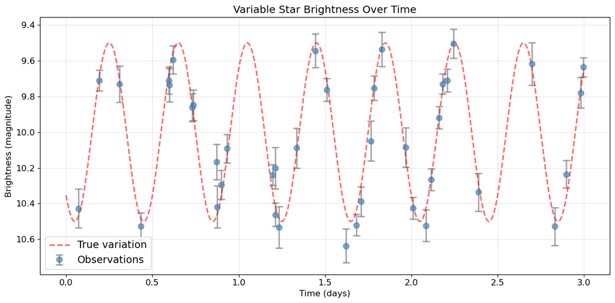

```python
# Create a smooth curve showing the true variation
time_smooth = np.linspace(0, 3, 500)
true_curve = (true_mean_brightness +
             true_amplitude * np.sin(2 * np.pi * true_frequency * time_smooth + true_phase))

# Plot
plt.figure(figsize=(12, 6))

# Plot observations with varying error bars
plt.errorbar(observation_times, observed_brightness, yerr=brightness_errors,
             fmt='o', markersize=8, capsize=5, capthick=2, alpha=0.7,
             color='steelblue', ecolor='gray', label='Observations')

# Plot true variation
plt.plot(time_smooth, true_curve, 'r--', linewidth=2, alpha=0.6,
        label='True variation')

plt.xlabel('Time (days)')
plt.ylabel('Brightness (magnitude)')
plt.title('Variable Star Brightness Over Time')
plt.gca().invert_yaxis()  # Invert y-axis: smaller magnitude = brighter
plt.legend(fontsize=14)
plt.grid(True, alpha=0.3)
plt.tight_layout()
plt.show()
```

Note: The y-axis is inverted because in astronomy's magnitude system, smaller numbers mean brighter objects. So upward variation on this plot means the star is getting brighter.

The sinusoidal pattern is clear despite the noise. The observations rise and fall periodically as the star pulsates or rotates. Note that we've inverted the y-axis - this is the standard way astronomers plot light curves, because the magnitude scale is backwards (smaller = brighter).

Now let's fit a sinusoidal model to these observations. First, we need to define our model function. This function will take time as the independent variable and the four parameters (mean, amplitude, frequency, phase) that `curve_fit` will optimize. It returns the predicted brightness at any given time using the sinusoidal formula with 2πf to convert frequency to angular units:

```python
def sinusoidal_model(time, mean_brightness, amplitude, frequency, phase):
    """
    Sinusoidal model for variable star brightness.

    Parameters:
    -----------
    time : array-like
        Time values in days (independent variable)
    mean_brightness : float
        Average brightness in magnitudes (parameter to fit)
    amplitude : float
        Variation amplitude in magnitudes (parameter to fit)
    frequency : float
        Frequency in cycles per day (parameter to fit)
    phase : float
        Phase offset in radians (parameter to fit)

    Returns:
    --------
    array
        Predicted brightness at each time
    """
    return mean_brightness + amplitude * np.sin(2 * np.pi * frequency * time + phase)
```

For non-linear models, providing good initial parameter guesses is important. The optimization algorithm uses these guesses as starting points, and poor guesses can cause it to converge to wrong solutions (local minima) or fail to converge at all.

Let's estimate reasonable initial guesses by inspecting our data. We'll calculate the mean brightness directly from the observations using `np.mean()`, estimate the amplitude as half the peak-to-peak range using `(max - min)/2`, make an educated guess for the frequency by visual inspection of how many cycles we see, and start with zero phase (which can be fitted from any starting point). We'll then combine these into an initial guess array to pass to `curve_fit`:

```python
# Estimate initial parameters from the observations
# Mean: the average of all observations
initial_mean = np.mean(observed_brightness)

# Amplitude: roughly half the peak-to-peak range
initial_amplitude = (np.max(observed_brightness) - np.min(observed_brightness)) / 2

# Frequency: estimate from the data by counting peaks
# A simple approach: look at the time span and number of bright/faint points
time_span = observation_times[-1] - observation_times[0]

# Estimate roughly how many cycles we see (very rough guess)
initial_frequency = 2.5  # Adjust based on visual inspection of ~6-7 cycles in ~3 days

# Phase: start with zero (we can fit any phase)
initial_phase = 0.0

# Combine into initial guess array
initial_guess = [initial_mean, initial_amplitude, initial_frequency, initial_phase]

print("Initial parameter guesses:")
print("=" * 50)
print(f"Mean brightness: {initial_mean:.3f} mag")
print(f"Amplitude: {initial_amplitude:.3f} mag")
print(f"Frequency: {initial_frequency:.1f} cycles/day")
print(f"Phase: {initial_phase:.1f} radians")
print("\nThese don't need to be perfect - just reasonable starting points")
print("for the optimization algorithm.")
```

```
Initial parameter guesses:
==================================================
Mean brightness: 10.053 mag
Amplitude: 0.566 mag
Frequency: 2.5 cycles/day
Phase: 0.0 radians

These don't need to be perfect - just reasonable starting points
for the optimization algorithm.
```

Our initial guesses are close to the true values, which should help the optimization converge quickly and reliably. Now let's fit the model using `curve_fit`. For this non-linear problem, we need to be more careful than with the linear fit. We'll provide our initial guesses via `p0` to help the algorithm start in the right region of parameter space. We'll also include `sigma=brightness_errors` to weight each observation by its uncertainty, and set `absolute_sigma=True` so these are treated as absolute errors rather than relative weights.

Crucially, we'll add `bounds` to prevent the optimizer from wandering into physically meaningless parameter values - for example, negative amplitude doesn't make sense, and we can constrain the frequency based on the observation timespan. Finally, `maxfev=5000` allows the algorithm up to 5000 function evaluations, which is sometimes needed for non-linear problems where the optimizer needs to explore the parameter space carefully.

Note: In this example, we have good initial guesses because we can inspect the data. In the last section of this lecture, we'll discuss strategies for tackling cases where we don't have good initial guesses - a common challenge in real-world optimization problems. Let's fit:

```python
# Fit the sinusoidal model
# We provide initial guesses via the p0 parameter
# We also set bounds to prevent nonsensical solutions (like negative amplitude)
popt, pcov = curve_fit(
    sinusoidal_model,              # The model function
    observation_times,             # Independent variable (time)
    observed_brightness,           # Dependent variable (brightness)
    p0=initial_guess,             # Initial parameter guesses
    sigma=brightness_errors,       # Measurement uncertainties (heterogeneous!)
    absolute_sigma=True,           # Treat sigma as absolute errors
    bounds=([9, 0, 0.5, -np.pi],   # Lower bounds: mean>9, amp>0, freq>0.5, phase>-π
            [11, 2, 5, np.pi]),    # Upper bounds: mean<11, amp<2, freq<5, phase<π
    maxfev=5000                    # Maximum function evaluations
)

# Extract fitted parameters
fitted_mean, fitted_amplitude, fitted_frequency, fitted_phase = popt

# Calculate fitted period
fitted_period = 1 / fitted_frequency

print("Fitted vs True Parameters:")
print("=" * 50)
print(f"Mean brightness:")
print(f"  Fitted: {fitted_mean:.3f} mag")
print(f"  True:   {true_mean_brightness:.3f} mag")
print(f"\nAmplitude:")
print(f"  Fitted: {fitted_amplitude:.3f} mag")
print(f"  True:   {true_amplitude:.3f} mag")
print(f"\nFrequency:")
print(f"  Fitted: {fitted_frequency:.3f} cycles/day")
print(f"  True:   {true_frequency:.3f} cycles/day")
print(f"\nPeriod:")
print(f"  Fitted: {fitted_period:.4f} days ({fitted_period*24:.2f} hours)")
print(f"  True:   {1/true_frequency:.4f} days ({24/true_frequency:.2f} hours)")
print(f"\nPhase:")
print(f"  Fitted: {fitted_phase:.3f} rad ({np.degrees(fitted_phase):.1f}°)")
print(f"  True:   {true_phase:.3f} rad ({np.degrees(true_phase):.1f}°)")
```

```
Fitted vs True Parameters:
==================================================
Mean brightness:
  Fitted: 10.009 mag
  True:   10.000 mag

Amplitude:
  Fitted: 0.482 mag
  True:   0.500 mag

Frequency:
  Fitted: 2.505 cycles/day
  True:   2.500 cycles/day

Period:
  Fitted: 0.3992 days (9.58 hours)
  True:   0.4000 days (9.60 hours)

Phase:
  Fitted: 0.742 rad (42.5°)
  True:   0.785 rad (45.0°)
```

Excellent agreement! The fitted parameters closely match the true values. The small differences reflect the measurement noise - with perfect data, we'd recover the true values exactly.

Now let's visualize how well the fitted model matches our observations. First, we'll calculate the fitted curve by calling our `sinusoidal_model` function with the optimized parameters and a smooth time grid. Then we'll create a plot comparing this fitted curve to both our noisy observations and the true underlying variation:

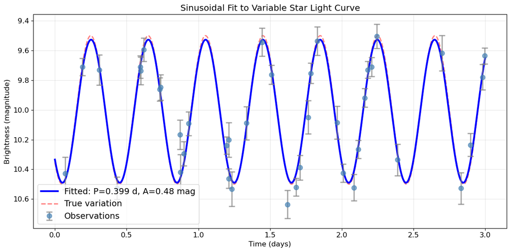

```python
# Calculate fitted curve
fitted_curve = sinusoidal_model(time_smooth, fitted_mean, fitted_amplitude,
                                fitted_frequency, fitted_phase)

# Plot
fig, ax = plt.subplots(figsize=(12, 6))

# Plot observations with varying error bars
ax.errorbar(observation_times, observed_brightness, yerr=brightness_errors,
           fmt='o', markersize=8, capsize=5, capthick=2, alpha=0.7,
           color='steelblue', ecolor='gray', label='Observations', zorder=3)

# Plot fitted curve
ax.plot(time_smooth, fitted_curve, 'b-', linewidth=3,
       label=f'Fitted: P={fitted_period:.3f} d, A={fitted_amplitude:.2f} mag', zorder=2)

# Plot true curve for comparison
ax.plot(time_smooth, true_curve, 'r--', linewidth=2, alpha=0.5,
       label='True variation', zorder=1)

ax.set_xlabel('Time (days)')
ax.set_ylabel('Brightness (magnitude)')
ax.set_title('Sinusoidal Fit to Variable Star Light Curve')
ax.invert_yaxis()
ax.legend(fontsize=14)
ax.grid(True, alpha=0.3)
plt.tight_layout()
plt.show()
```

The blue curve (our fitted model) beautifully captures the periodic variation in the observations. It's nearly identical to the red dashed line (the true variation), confirming that we've successfully extracted the physical parameters - the pulsation period and amplitude - from noisy measurements.

This demonstrates the power of non-linear curve fitting. Even though the model is more complex than a simple line, `curve_fit` navigated the four-dimensional parameter space to find the combination of mean, amplitude, frequency, and phase that best matches our observations.

Now let's extract the parameter uncertainties from the covariance matrix. We'll use `np.sqrt(np.diag(pcov))` to get the standard errors for all four parameters, then unpack them into individual variables. We'll print each parameter with its uncertainty to see how precisely we've determined the star's variability properties:

```python
# Extract parameter uncertainties from covariance matrix
param_uncertainties = np.sqrt(np.diag(pcov))
mean_err, amplitude_err, frequency_err, phase_err = param_uncertainties

# Calculate period uncertainty using error propagation
# Period = 1/frequency, so $\sigma$_period = (∂P/∂f) $\times$ $\sigma$_f = (1/f²) $\times$ $\sigma$_f
period_err = (1/fitted_frequency**2) * frequency_err

print("Parameter Uncertainties:")
print("=" * 50)
print(f"Mean brightness: {fitted_mean:.3f} ± {mean_err:.3f} mag")
print(f"Amplitude: {fitted_amplitude:.3f} ± {amplitude_err:.3f} mag")
print(f"Frequency: {fitted_frequency:.3f} ± {frequency_err:.3f} cycles/day")
print(f"Period: {fitted_period:.4f} ± {period_err:.4f} days")
print(f"Phase: {fitted_phase:.3f} ± {phase_err:.3f} radians")
```

```
Parameter Uncertainties:
==================================================
Mean brightness: 10.009 ± 0.013 mag
Amplitude: 0.482 ± 0.018 mag
Frequency: 2.505 ± 0.007 cycles/day
Period: 0.3992 ± 0.0012 days
Phase: 0.742 ± 0.080 radians
```

## Binary Stars: Fitting Radial Velocity Curves

Now let's tackle a more sophisticated astronomical application: analyzing a **binary star system**. Binary stars are pairs of stars orbiting their common center of mass, bound together by gravity. They're incredibly important in astronomy because they provide the only direct way to measure stellar masses - a fundamental property that determines everything about a star's life: how bright it will be, how long it will live, and how it will die.

When we observe a binary star system, we typically can't resolve the individual stars - they're too close together and too far away. Instead, we detect their presence through the **Doppler effect**. As the stars orbit, they alternately move toward us and away from us. When a star moves toward us, its light is blueshifted - the wavelengths are compressed. When it moves away, the light is redshifted - the wavelengths are stretched. By measuring these wavelength shifts in the star's spectrum, we can determine its **radial velocity** - the component of velocity along our line of sight.

The key insight is that radial velocity varies periodically as the star orbits. When the star is moving toward us, the radial velocity is negative (approaching). When it's moving away, the radial velocity is positive (receding). Half an orbit later, the situation reverses. By measuring this periodic velocity variation over time and fitting an orbital model, we can determine the orbital parameters.

For a circular orbit, the radial velocity as a function of time is given by:

$$v_r(t) = v_{sys} + K \sin\left(\frac{2\pi}{P}(t - t_0)\right)$$

where:

- $v_{sys}$ is the **systemic velocity** - the velocity of the entire binary system through space (relative to Earth)
- $K$ is the **semi-amplitude** - the maximum radial velocity (how fast the star moves in its orbit)
- $P$ is the **orbital period** - how long one complete orbit takes
- $t_0$ is the **time of periastron** or a reference time when the star crosses a particular phase
- $t$ is the observation time

You might notice this equation looks similar to our variable star model from earlier - both describe sinusoidal variations! In fact, this is just a reparametrization of the same mathematical form. However, we choose this specific parametrization (with period $P$ and reference time $t_0$ rather than frequency and phase) because it's more physically meaningful for orbital mechanics. As we'll see shortly, the orbital period $P$ directly relates to the stellar masses through Kepler's laws, making it the natural parameter to work with when our goal is to determine the physical properties of the binary system.

#### Visualizing the Orbital Motion and Radial Velocity

To understand what we're measuring with radial velocities, let's visualize the physical setup. When a companion star orbits, its motion along our line of sight produces periodic Doppler shifts - the star appears to move toward us (blue-shifted) and away from us (red-shifted) over the orbital period. Let's create a diagram showing the orbital geometry alongside the resulting radial velocity curve:

[figure not shown]

```python
# Create visualization of binary orbit and radial velocity curve
fig = plt.figure(figsize=(14, 6))
gs = fig.add_gridspec(1, 2, width_ratios=[1, 1])
ax_orbit = fig.add_subplot(gs[0])
ax_rv = fig.add_subplot(gs[1])

# Orbital parameters (using our fitted values)
orbit_radius = 1.0
theta = np.linspace(0, 2*np.pi, 100)
x_orbit = orbit_radius * np.cos(theta)
y_orbit = orbit_radius * np.sin(theta)

# Plot the orbit (left panel) - edge-on view
ax_orbit.plot(x_orbit, y_orbit, 'gray', linewidth=2, linestyle='--', alpha=0.5)

# Mark four key phases
phases = [0, np.pi/2, np.pi, 3*np.pi/2]
phase_labels = ['Max\nreceding', 'Zero\nvelocity', 'Max\napproaching', 'Zero\nvelocity']
phase_colors = ['blue', 'gray', 'red', 'gray']
arrow_colors = ['blue', None, 'red', None]

for i, (phase, label, color, arrow_color) in enumerate(zip(phases, phase_labels, phase_colors, arrow_colors)):
    x = orbit_radius * np.cos(phase)
    y = orbit_radius * np.sin(phase)
    ax_orbit.plot(x, y, 'o', color=color, markersize=12,
                 markeredgecolor='black', markeredgewidth=1.5)

    # Add arrows showing motion direction
    if arrow_color:
        if i == 0:  # Moving away (down)
            ax_orbit.arrow(x, y, 0, -0.2, head_width=0.08, head_length=0.06,
                          fc=arrow_color, ec=arrow_color, linewidth=2)
        elif i == 2:  # Moving toward (up)
            ax_orbit.arrow(x, y, 0, 0.2, head_width=0.08, head_length=0.06,
                          fc=arrow_color, ec=arrow_color, linewidth=2)

    # Add labels
    label_offset = 1.3
    ax_orbit.text(x * label_offset, y * label_offset, label,
                 ha='center', va='center', fontsize=10, color=color, fontweight='bold')

# Central star
ax_orbit.plot(0, 0, '*', color='gold', markersize=20, markeredgecolor='orange',
             markeredgewidth=1.5, label='Primary star', zorder=10)

# Add "To Earth" arrow
ax_orbit.annotate('To Earth', xy=(0, -1.4), xytext=(0, -1.6),
                 arrowprops=dict(arrowstyle='->', lw=2, color='black'),
                 fontsize=11, ha='center', fontweight='bold')

ax_orbit.set_xlim(-1.6, 1.6)
ax_orbit.set_ylim(-1.8, 1.6)
ax_orbit.set_aspect('equal')
ax_orbit.set_xlabel('Sky Plane', fontsize=11)
ax_orbit.set_ylabel('Line of Sight', fontsize=11)
ax_orbit.set_title('Orbital Motion (Edge-On View)', fontsize=12, fontweight='bold')
ax_orbit.grid(True, alpha=0.3)
ax_orbit.axhline(0, color='gray', linestyle='--', linewidth=1, alpha=0.5)
ax_orbit.axvline(0, color='gray', linestyle='--', linewidth=1, alpha=0.5)

# Plot radial velocity curve (right panel) - using example values
# For illustration: P = 5.7 days, K = 45 km/s (typical for a close binary)
example_P = 5.7  # Orbital period in days
example_K = 45.0  # Velocity semi-amplitude in km/s

time = np.linspace(0, example_P, 200)
rv = example_K * np.sin(2 * np.pi * time / example_P)

ax_rv.plot(time, rv, 'purple', linewidth=2.5, label='Radial Velocity')
ax_rv.axhline(0, color='gray', linestyle='--', linewidth=1.5, alpha=0.5)

# Mark the four phases on the RV curve
phase_times = [0, example_P/4, example_P/2, 3*example_P/4]
phase_rvs = [example_K * np.sin(2 * np.pi * t / example_P) for t in phase_times]

for t, rv_val, color in zip(phase_times, phase_rvs, phase_colors):
    ax_rv.plot(t, rv_val, 'o', color=color, markersize=12,
              markeredgecolor='black', markeredgewidth=1.5)

# Shade regions
ax_rv.fill_between(time, 0, rv, where=(rv >= 0), alpha=0.2, color='blue', label='Receding (redshift)')
ax_rv.fill_between(time, 0, rv, where=(rv < 0), alpha=0.2, color='red', label='Approaching (blueshift)')

ax_rv.set_xlabel('Time (days)', fontsize=11)
ax_rv.set_ylabel('Radial Velocity (km/s)', fontsize=11)
ax_rv.set_title('Radial Velocity Curve', fontsize=12, fontweight='bold')
ax_rv.legend(loc='upper right', fontsize=12)
ax_rv.grid(True, alpha=0.3)

plt.tight_layout()
plt.show()
```

#### The Role of Orbital Inclination

This equation describes a circular orbit, but there's an important caveat: we can only measure the component of the star's motion along our line of sight (the radial velocity). The star is actually moving in a circle, but if the orbital plane is tilted relative to our line of sight, we see only a projection of that motion. This angle between the orbital plane and our line of sight is called the **orbital inclination**, denoted $i$. When $i = 90^\circ$ (edge-on), we see the full orbital motion. When $i = 0^\circ$ (face-on), we see no radial velocity variation at all. Most binary systems fall somewhere in between. The velocity amplitude $K$ we measure is actually $K_\text{true} \times \sin(i)$, where $K_\text{true}$ is the true orbital speed. This means radial velocity measurements alone give us $M \sin(i)$ (mass times sine of inclination), not the true mass.

From these four parameters ($v_{sys}$, $K$, $P$, and $t_0$), we can calculate the **mass function**, which provides constraints on the stellar masses.

#### Visualizing the Effect of Orbital Inclination

To understand how orbital inclination affects what we observe, let's first visualize the geometry. We'll show the same circular orbit as viewed from three different angles: edge-on ($i = 90^\circ$), intermediate ($i = 60^\circ$), and nearly face-on ($i = 30^\circ$).

For each viewing angle, we'll create a 3D circular orbit and project it onto our viewing plane. The key insight: when the orbit is tilted, we lose information about the star's motion perpendicular to our line of sight. We only measure the radial component (toward/away from us), not the tangential component (side-to-side):

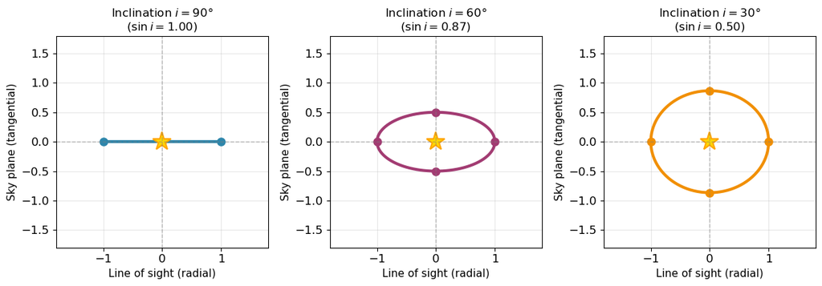

```python
# Create a circular orbit for visualization
theta = np.linspace(0, 2*np.pi, 100)
orbit_radius = 1.0  # Arbitrary units

# Three viewing angles to demonstrate
inclinations = [90, 60, 30]  # degrees
colors = ['#2E86AB', '#A23B72', '#F18F01']

fig, axes = plt.subplots(1, 3, figsize=(12, 4))

for idx, (inclination, color) in enumerate(zip(inclinations, colors)):
    ax = axes[idx]

    # Create circular orbit in 3D
    # x: along line of sight (toward observer)
    # y: perpendicular (left-right from observer's view)
    # z: perpendicular (up-down from observer's view)
    inclination_rad = np.radians(inclination)

    # True circular orbit in orbital plane
    x_orbit = orbit_radius * np.cos(theta)  # Radial motion component
    y_orbit = orbit_radius * np.sin(theta) * np.cos(inclination_rad)  # Projected tangential
    z_orbit = orbit_radius * np.sin(theta) * np.sin(inclination_rad)  # Out of plane

    # Plot the projected orbit (as we see it from Earth)
    ax.plot(x_orbit, y_orbit, color=color, linewidth=3, label='Observed orbit')

    # Mark a few positions along the orbit
    positions = [0, np.pi/2, np.pi, 3*np.pi/2]
    for pos in positions:
        y_pos = orbit_radius * np.sin(pos) * np.cos(inclination_rad)
        x_pos = orbit_radius * np.cos(pos)
        ax.plot(x_pos, y_pos, 'o', color=color, markersize=8)

    # Mark the star at center
    ax.plot(0, 0, '*', color='gold', markersize=20, markeredgecolor='orange',
            markeredgewidth=1.5, label='Primary star')

    # Formatting
    ax.set_xlim(-1.8, 1.8)
    ax.set_ylim(-1.8, 1.8)
    ax.set_aspect('equal')
    ax.set_xlabel('Line of sight (radial)', fontsize=11)
    ax.set_ylabel('Sky plane (tangential)', fontsize=11)
    ax.set_title(f'Inclination $i = {inclination}°$\n($\\sin i = {np.sin(inclination_rad):.2f}$)',
                 fontsize=12)
    ax.grid(True, alpha=0.3)
    ax.axhline(0, color='gray', linestyle='--', linewidth=1, alpha=0.5)
    ax.axvline(0, color='gray', linestyle='--', linewidth=1, alpha=0.5)

plt.tight_layout()
plt.show()
```

Now let's see how these geometric projections manifest in the observed radial velocity curves. We'll use the same three inclinations and show how the RV amplitude varies with viewing angle:

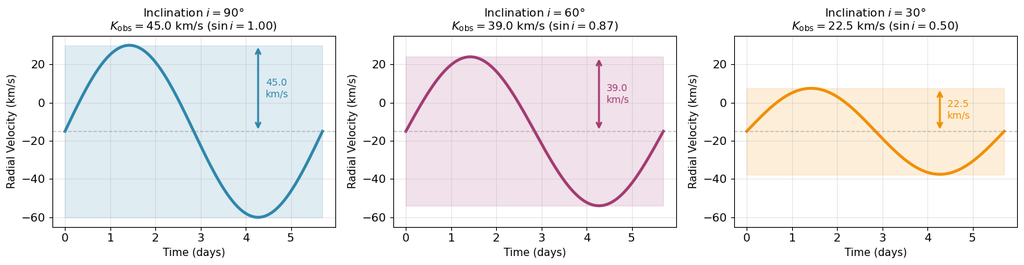

```python
# Set up parameters for radial velocity curves
K_true = 45.0      # True orbital velocity amplitude in km/s
P = 5.7            # Orbital period in days
vsys = -15.0       # Systemic velocity in km/s
t0 = 0.0           # Reference time

# Three different orbital inclinations to demonstrate
inclinations = [90, 60, 30]  # degrees
colors = ['#2E86AB', '#A23B72', '#F18F01']

# Create time array for smooth curves (one complete orbit)
time_orbit = np.linspace(0, P, 200)

# Create 3-panel figure
fig, axes = plt.subplots(1, 3, figsize=(15, 4))

for idx, (inclination, color) in enumerate(zip(inclinations, colors)):
    ax = axes[idx]

    # Calculate observed amplitude (projection effect)
    inclination_rad = np.radians(inclination)
    K_observed = K_true * np.sin(inclination_rad)

    # Calculate radial velocity curve
    rv_curve = K_observed * np.sin(2 * np.pi * (time_orbit - t0) / P) + vsys

    # Plot the radial velocity curve
    ax.plot(time_orbit, rv_curve, color=color, linewidth=3)
    ax.axhline(vsys, color='gray', linestyle='--', linewidth=1, alpha=0.5,
               label='Systemic velocity')
    ax.fill_between(time_orbit, vsys - K_observed, vsys + K_observed,
                     color=color, alpha=0.15)

    # Formatting
    ax.set_xlabel('Time (days)', fontsize=11)
    ax.set_ylabel('Radial Velocity (km/s)', fontsize=11)
    ax.set_title(f'Inclination $i = {inclination}°$\n' +
                 f'$K_{{\\rm obs}} = {K_observed:.1f}$ km/s ' +
                 f'$(\\sin i = {np.sin(inclination_rad):.2f})$',
                 fontsize=12)
    ax.grid(True, alpha=0.3)
    ax.set_ylim(-65, 35)

    # Add annotation showing amplitude
    ax.annotate('', xy=(P*0.75, vsys + K_observed), xytext=(P*0.75, vsys),
                arrowprops=dict(arrowstyle='<->', color=color, lw=2))
    ax.text(P*0.78, vsys + K_observed/2, f'{K_observed:.1f}\nkm/s',
            fontsize=10, color=color, va='center')

plt.tight_layout()
plt.show()
```

The three-panel plot reveals the critical effect of viewing angle on radial velocity observations. With the same true orbital velocity of 45 km/s:

- **Edge-on ($i = 90^\circ$)**: We observe the full amplitude of 45.0 km/s because $\sin(90^\circ) = 1$
- **Intermediate ($i = 60^\circ$)**: We observe a reduced amplitude of 39.0 km/s because $\sin(60^\circ) = 0.87$
- **Nearly face-on ($i = 30^\circ$)**: We observe only 22.5 km/s because $\sin(30^\circ) = 0.50$

This visualization clearly shows why the $\sin(i)$ factor is so important: the same physical orbit produces dramatically different observed radial velocity amplitudes depending on our viewing angle. This is why radial velocity surveys can only measure $M \sin(i)$ for exoplanets and stellar companions—the true mass remains uncertain unless we can independently determine the inclination (for example, from transits, eclipses, or astrometric measurements).

```python
# True orbital parameters of the binary system
true_K = 45.0           # Semi-amplitude in km/s
true_P = 5.7            # Orbital period in days
true_t0 = 1.2           # Reference time in days
true_vsys = -15.0       # Systemic velocity in km/s

print("Binary Star System Parameters:")
print("=" * 50)
print(f"Orbital period: {true_P} days")
print(f"Velocity semi-amplitude: {true_K} km/s")
print(f"Systemic velocity: {true_vsys} km/s")
print(f"Reference time: {true_t0} days")
```

```
Binary Star System Parameters:
==================================================
Orbital period: 5.7 days
Velocity semi-amplitude: 45.0 km/s
Systemic velocity: -15.0 km/s
Reference time: 1.2 days
```

Physical interpretation of these orbital parameters:

A velocity amplitude of 45 km/s is typical for a close binary system. To put this in perspective, Earth orbits the Sun at about 30 km/s, so these stars are moving quite fast! The period of 5.7 days means they're very close together - much closer than Mercury is to our Sun.

```python
# Simulate realistic observation times over 20 days
n_obs = 30
observation_times = np.sort(np.random.uniform(0, 20, n_obs))

print(f"\nObservation campaign:")
print(f"  Duration: {observation_times[-1]:.1f} days")
print(f"  Number of observations: {n_obs}")
print(f"  Number of orbital cycles covered: {observation_times[-1]/true_P:.1f}")
```

```
Observation campaign:
  Duration: 17.1 days
  Number of observations: 30
  Number of orbital cycles covered: 3.0
```

Now let's define our radial velocity model as a Python function. This function will take time as the independent variable and the four orbital parameters ($K$, $P$, $t_0$, $v_{sys}$) that we want to fit. The function calculates the orbital phase at each time, then returns the radial velocity using the sinusoidal model. This is the mathematical relationship we'll fit to our observations:

```python
def radial_velocity_model(t, K, P, t0, vsys):
    """
    Radial velocity model for a binary star in circular orbit.

    Parameters:
    -----------
    t : array-like
        Time values in days (independent variable)
    K : float
        Semi-amplitude in km/s (parameter to fit)
    P : float
        Orbital period in days (parameter to fit)
    t0 : float
        Reference time in days (parameter to fit)
    vsys : float
        Systemic velocity in km/s (parameter to fit)

    Returns:
    --------
    array
        Radial velocities at each time in km/s
    """
    # Calculate the orbital phase at each time
    phase = 2 * np.pi * (t - t0) / P

    # Calculate radial velocity: systemic velocity + orbital variation
    return vsys + K * np.sin(phase)
```

Now let's calculate the true radial velocities at our observation times. We'll use our `radial_velocity_model` function with the true orbital parameters ($K$, $P$, $t_0$, $v_{sys}$) to compute what a perfect observer would measure at each observation time. These represent the actual orbital motion without any measurement noise:

```python
# Calculate true radial velocities
true_velocities = radial_velocity_model(observation_times, true_K, true_P, true_t0, true_vsys)
```

In real spectroscopic observations, measuring radial velocities involves cross-correlating the observed spectrum with a template to measure the Doppler shift. This process has uncertainties due to photon noise (too few photons collected), spectral resolution (the spectrograph's ability to distinguish wavelengths), and systematic effects. Different observations have different signal-to-noise ratios depending on conditions and exposure time.

Let's simulate this realistic scenario. We'll generate heterogeneous measurement uncertainties using `np.random.uniform()` to create varying errors between 0.5 and 1.5 km/s (typical for moderate-resolution spectroscopy). Then we'll add noise to each velocity value, where the noise for each observation is drawn from a normal distribution with that observation's specific uncertainty. Finally, we'll display some sample observations with their varying error bars:

```python
# Generate heterogeneous measurement uncertainties
# Spectroscopy quality varies due to weather, exposure time, stellar brightness, etc.
np.random.seed(45)  # Different seed for velocity errors
velocity_errors = np.random.uniform(0.5, 1.5, n_obs)  # Range of typical RV uncertainties in km/s

# Add measurement noise according to each observation's uncertainty
noise = np.array([np.random.normal(0, sigma) for sigma in velocity_errors])
observed_velocities = true_velocities + noise

print("Sample observations:")
print(f"{'Time (days)':<15} {'Velocity (km/s)':<20} {'Error (km/s)':<15}")
print("=" * 50)
for i in range(5):
    print(f"{observation_times[i]:<15.2f} {observed_velocities[i]:<20.2f} {velocity_errors[i]:<15.3f}")
print("...")
print(f"\nVelocity uncertainties range: {velocity_errors.min():.3f} to {velocity_errors.max():.3f} km/s")
```

```
Sample observations:
Time (days)     Velocity (km/s)      Error (km/s)
==================================================
0.01            -59.47               1.489
0.05            -57.59               1.050
1.28            -12.10               0.781
1.98            20.00                0.577
2.34            27.30                0.944
...

Velocity uncertainties range: 0.549 to 1.491 km/s
```

Let's visualize the radial velocity curve. We'll create a smooth version of the true orbital curve for comparison, then plot our observations with their varying error bars. The plot will show the characteristic sinusoidal pattern as the star moves toward and away from us in its orbit, with a horizontal line marking the systemic velocity (the center-of-mass velocity of the binary system):

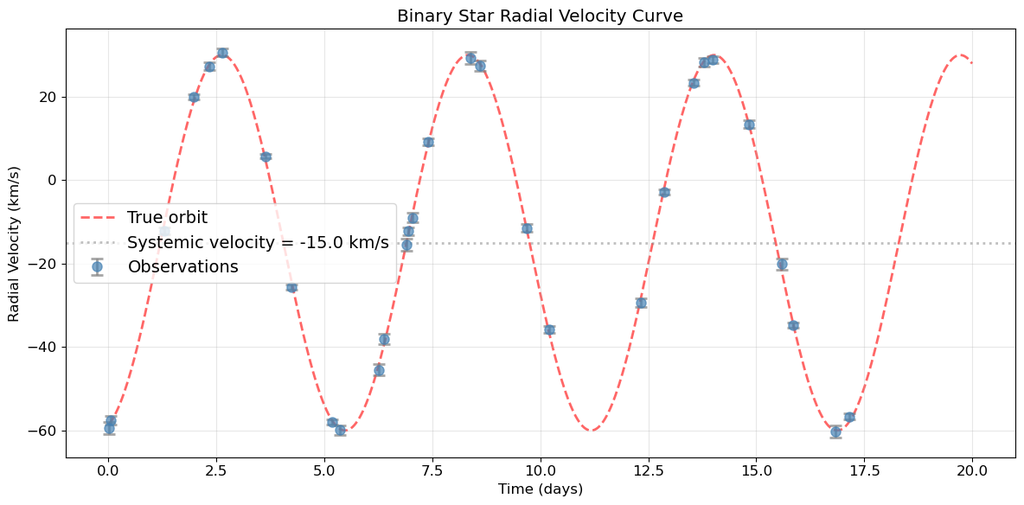

```python
# Create smooth curve for visualization
time_smooth = np.linspace(0, 20, 500)
true_rv_curve = radial_velocity_model(time_smooth, true_K, true_P, true_t0, true_vsys)

# Plot
fig, ax = plt.subplots(figsize=(12, 6))

# Plot observations with varying error bars
ax.errorbar(observation_times, observed_velocities, yerr=velocity_errors,
           fmt='o', markersize=8, capsize=5, capthick=2, alpha=0.7,
           color='steelblue', ecolor='gray', label='Observations', zorder=3)

# Plot true orbit
ax.plot(time_smooth, true_rv_curve, 'r--', linewidth=2, alpha=0.6,
       label='True orbit', zorder=1)

# Mark systemic velocity
ax.axhline(true_vsys, color='gray', linestyle=':', linewidth=2, alpha=0.5,
          label=f'Systemic velocity = {true_vsys} km/s')

ax.set_xlabel('Time (days)')
ax.set_ylabel('Radial Velocity (km/s)')
ax.set_title('Binary Star Radial Velocity Curve')
ax.legend(fontsize=14)
ax.grid(True, alpha=0.3)
plt.tight_layout()
plt.show()
```

Interpretation of the curve: When the velocity is negative (below the systemic velocity line), the star is moving toward us and its light is blueshifted. When the velocity is positive (above the systemic velocity line), the star is moving away and its light is redshifted. The sinusoidal pattern is the characteristic signature of orbital motion - as the star goes around in its orbit, we see it alternately approaching and receding from us.

The sinusoidal pattern is the signature of orbital motion. The gray dashed line shows the systemic velocity - the overall motion of the binary through space. The oscillation around this line is the star's orbital motion. When the curve is at its lowest point, the star is moving toward us at maximum speed. When it's at its highest point, the star is moving away at maximum speed.

Now let's fit the orbital model to extract the parameters. First, we need to estimate initial guesses for the four parameters. We'll calculate the systemic velocity as the mean of all observations (the center of the oscillation), estimate the semi-amplitude $K$ as half the peak-to-peak variation, make a rough guess for the period based on visual inspection, and use the first observation time as the reference time $t_0$. We'll combine these into an initial parameter array:

```python
# Estimate initial parameters from observations
# Systemic velocity: approximately the mean radial velocity
initial_vsys = np.mean(observed_velocities)

# Semi-amplitude: approximately half the peak-to-peak variation
initial_K = (np.max(observed_velocities) - np.min(observed_velocities)) / 2

# Period: harder to estimate by eye, but we can guess a reasonable value
# Looking at the pattern, we see a few complete cycles in 20 days
initial_P = 6.0  # Rough guess

# Reference time: use the first observation time as starting point
initial_t0 = observation_times[0]

initial_params = [initial_K, initial_P, initial_t0, initial_vsys]

print("Initial parameter guesses:")
print("=" * 50)
print(f"Semi-amplitude K: {initial_K:.1f} km/s")
print(f"Period P: {initial_P:.1f} days")
print(f"Reference time t0: {initial_t0:.1f} days")
print(f"Systemic velocity vsys: {initial_vsys:.1f} km/s")
```

```
Initial parameter guesses:
==================================================
Semi-amplitude K: 45.5 km/s
Period P: 6.0 days
Reference time t0: 0.0 days
Systemic velocity vsys: -13.3 km/s
```

These are rough estimates to help the algorithm converge. They don't need to be perfect - just reasonable starting points in the right ballpark.

Now let's fit the orbital model using `curve_fit`. We pass our `radial_velocity_model` function (which must take the independent variable first, then the parameters to fit), followed by our observation times and measured velocities. The `p0` argument provides our initial guesses, `sigma=velocity_errors` includes our heterogeneous measurement uncertainties to properly weight each observation, and `absolute_sigma=True` ensures these are interpreted as absolute errors. We set `maxfev=5000` to allow enough iterations for this four-parameter non-linear fit to converge. The function returns `popt` (optimal parameter values) and `pcov` (the covariance matrix, from which we'll extract parameter uncertainties):

```python
# Fit the radial velocity curve
# We include measurement errors via the sigma parameter
# This weights the observations properly - more precise measurements have more influence
popt, pcov = curve_fit(
    radial_velocity_model,         # The model function
    observation_times,              # Independent variable (time)
    observed_velocities,            # Dependent variable (radial velocity)
    p0=initial_params,             # Initial parameter guesses
    sigma=velocity_errors,          # Measurement uncertainties (heterogeneous!)
    absolute_sigma=True,            # Treat sigma as absolute errors
    maxfev=5000                     # Maximum function evaluations
)

# Extract fitted parameters
fitted_K, fitted_P, fitted_t0, fitted_vsys = popt

print("Fitted Orbital Parameters:")
print("=" * 50)
print(f"Semi-amplitude K:")
print(f"  Fitted: {fitted_K:.2f} km/s")
print(f"  True:   {true_K:.2f} km/s")
print(f"\nOrbital period P:")
print(f"  Fitted: {fitted_P:.3f} days")
print(f"  True:   {true_P:.3f} days")
print(f"\nReference time t0:")
print(f"  Fitted: {fitted_t0:.3f} days")
print(f"  True:   {true_t0:.3f} days")
print(f"\nSystemic velocity vsys:")
print(f"  Fitted: {fitted_vsys:.2f} km/s")
print(f"  True:   {true_vsys:.2f} km/s")
```

```
Fitted Orbital Parameters:
==================================================
Semi-amplitude K:
  Fitted: 45.03 km/s
  True:   45.00 km/s

Orbital period P:
  Fitted: 5.698 days
  True:   5.700 days

Reference time t0:
  Fitted: 1.204 days
  True:   1.200 days

Systemic velocity vsys:
  Fitted: -15.03 km/s
  True:   -15.00 km/s
```

Excellent agreement! The fitted parameters closely match the true values. Now let's extract the parameter uncertainties from the covariance matrix. The diagonal elements of `pcov` contain the variances of each parameter, so we take the square root to get the standard errors (uncertainties). These uncertainties tell us how confident we are in each fitted parameter - smaller uncertainties mean more precise determinations:

```python
# Extract parameter uncertainties
param_uncertainties = np.sqrt(np.diag(pcov))
K_err, P_err, t0_err, vsys_err = param_uncertainties

print("\nParameter Uncertainties:")
print("=" * 50)
print(f"Semi-amplitude K: {fitted_K:.2f} ± {K_err:.2f} km/s")
print(f"Period P: {fitted_P:.3f} ± {P_err:.3f} days")
print(f"Reference time t0: {fitted_t0:.3f} ± {t0_err:.3f} days")
print(f"Systemic velocity vsys: {fitted_vsys:.2f} ± {vsys_err:.2f} km/s")
print("\nThese uncertainties tell us how precisely we've determined each parameter.")
```

```
Parameter Uncertainties:
==================================================
Semi-amplitude K: 45.03 ± 0.24 km/s
Period P: 5.698 ± 0.005 days
Reference time t0: 1.204 ± 0.008 days
Systemic velocity vsys: -15.03 ± 0.16 km/s

These uncertainties tell us how precisely we've determined each parameter.
```

Now let's visualize the fit to see how well our model matches the observations. We'll calculate the fitted curve using our optimized parameters, then plot it alongside the observations and the true curve. The fitted curve should closely match both the data points and the true underlying orbit, demonstrating that `curve_fit` successfully extracted the orbital parameters from noisy measurements:

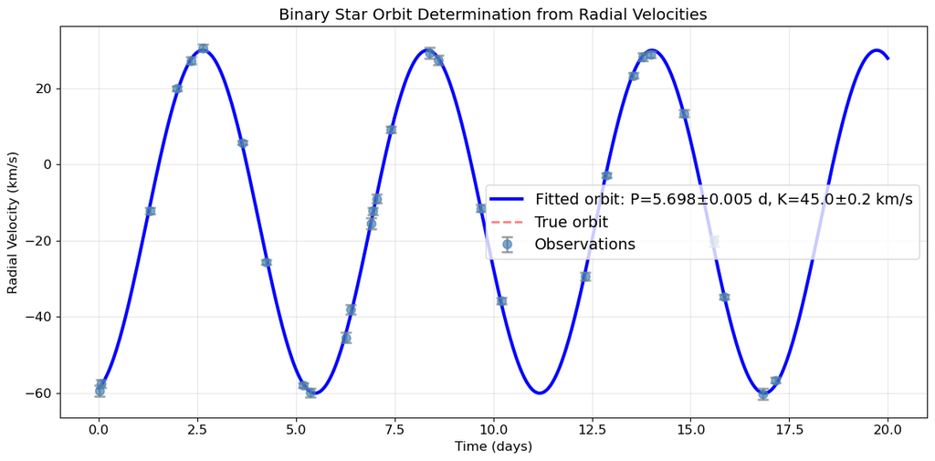

```python
# Calculate fitted curve
fitted_rv_curve = radial_velocity_model(time_smooth, fitted_K, fitted_P, fitted_t0, fitted_vsys)

# Plot
fig, ax = plt.subplots(figsize=(12, 6))

# Plot observations with varying error bars
ax.errorbar(observation_times, observed_velocities, yerr=velocity_errors,
           fmt='o', markersize=8, capsize=5, capthick=2, alpha=0.7,
           color='steelblue', ecolor='gray', label='Observations', zorder=3)

# Plot fitted curve
ax.plot(time_smooth, fitted_rv_curve, 'b-', linewidth=3,
       label=f'Fitted orbit: P={fitted_P:.3f}$\pm${P_err:.3f} d, K={fitted_K:.1f}$\pm${K_err:.1f} km/s',
       zorder=2)

# Plot true curve for comparison
ax.plot(time_smooth, true_rv_curve, 'r--', linewidth=2, alpha=0.5,
       label='True orbit', zorder=1)

ax.set_xlabel('Time (days)')
ax.set_ylabel('Radial Velocity (km/s)')
ax.set_title('Binary Star Orbit Determination from Radial Velocities')
ax.legend(fontsize=14)
ax.grid(True, alpha=0.3)
plt.tight_layout()
plt.show()
```

The blue curve (our fitted orbit) beautifully matches the observations and closely follows the true orbit. We've successfully extracted the orbital parameters from noisy velocity measurements!

## From Orbits to Masses: Physical Interpretation

The orbital parameters we've measured aren't just abstract numbers - they directly constrain the physical properties of the binary system, particularly the stellar masses. The **mass function** relates observable quantities to the masses:

$$f(M) = \frac{(M_2 \sin i)^3}{(M_1 + M_2)^2} = \frac{P K^3}{2\pi G}$$

Where:

- $M_1$ and $M_2$ are the masses of the two stars
- $i$ is the orbital inclination (angle between orbital plane and our line of sight)
- $P$ is the orbital period
- $K$ is the velocity semi-amplitude
- $G$ is the gravitational constant

The beauty of this equation is that the right side contains only measured quantities ($P$ and $K$), while the left side contains the masses we want to know. This mass function provides a lower limit on the companion star's mass.

Let's calculate the mass function from our fitted parameters. We'll first define physical constants (gravitational constant G and solar mass for unit conversion), then convert our fitted parameters from astronomical units (days, km/s) to SI units (seconds, m/s). We'll apply the mass function formula $f(M) = (P K^3) / (2\pi G)$ and convert the result to solar masses for easier interpretation:

```python
# Physical constants
G = 6.67430e-11  # Gravitational constant in m³ kg⁻¹ s⁻²
solar_mass = 1.989e30  # Solar mass in kg

# Convert fitted parameters to SI units
P_seconds = fitted_P * 86400  # Convert days to seconds
K_mps = fitted_K * 1000  # Convert km/s to m/s

# Calculate mass function: f(M) = (P $\times$ K³) / (2π $\times$ G)
mass_function_kg = (P_seconds * K_mps**3) / (2 * np.pi * G)
mass_function_solar = mass_function_kg / solar_mass

print("Mass Function Calculation:")
print("=" * 50)
print(f"From fitted parameters:")
print(f"  Period P = {fitted_P:.3f} days = {P_seconds:.0f} seconds")
print(f"  Semi-amplitude K = {fitted_K:.2f} km/s = {K_mps:.0f} m/s")
print(f"\nMass function:")
print(f"  f(M) = {mass_function_solar:.4f} solar masses")
```

```
Mass Function Calculation:
==================================================
From fitted parameters:
  Period P = 5.698 days = 492283 seconds
  Semi-amplitude K = 45.03 km/s = 45031 m/s

Mass function:
  f(M) = 0.0539 solar masses
```

Now let's interpret what this tells us about the system. The mass function provides a lower limit on the companion mass, but to estimate the actual companion mass, we need to solve the full mass function equation. Since we're observing a single-lined spectroscopic binary (we only see one star's spectrum), we cannot independently measure the orbital inclination or the primary star's mass. However, we can explore different scenarios by making reasonable assumptions. This is a perfect application for **`fsolve`** from `scipy.optimize`!

### Solving for Companion Mass with `fsolve`

To find the companion mass, we need to solve the mass function equation. Given assumed values for $M_1$ (the primary star mass) and $\sin i$ (the sine of the orbital inclination), the mass function equation becomes a nonlinear equation in $M_2$:

$$f(M) = \frac{(M_2 \sin i)^3}{(M_1 + M_2)^2}$$

Rearranging this to find the root (where the equation equals zero):

$$f(M) \cdot (M_1 + M_2)^2 - (M_2 \sin i)^3 = 0$$

This is a nonlinear equation that we can solve numerically using **`fsolve`**! This function finds the value of $M_2$ that makes the equation equal to zero. This approach works for any combination of masses and inclination angles.

Let's set up the equation as a Python function. The function takes $M_2$ as the variable to solve for, and accepts $f(M)$, $M_1$, and $\sin i$ as parameters. It returns the difference between the left and right sides of the mass function equation. When this difference is zero, we've found the correct $M_2$:

```python
from scipy.optimize import fsolve

def mass_function_equation(M2, f_M, M1, sin_i):
    """
    Mass function equation to solve for companion mass M2.

    This function returns zero when M2 satisfies the mass function equation:
    f(M) = (M2 * sin(i))^3 / (M1 + M2)^2

    Parameters:
    -----------
    M2 : float
        Companion mass (in solar masses) - the variable we're solving for
    f_M : float
        Mass function value (in solar masses) from observations
    M1 : float
        Primary star mass (in solar masses) - assumed value
    sin_i : float
        Sine of orbital inclination - assumed value

    Returns:
    --------
    float
        Difference between calculated and observed mass function
        (zero when M2 is correct)
    """
    # Left side: mass function from observation
    left_side = f_M * (M1 + M2)**2

    # Right side: mass function from masses and inclination
    right_side = (M2 * sin_i)**3

    # Return difference (should be zero at the solution)
    return left_side - right_side
```

The key insight is that `fsolve` will iteratively adjust $M_2$ until this function returns zero (or very close to zero). The `args` parameter will allow us to pass the known values ($f(M)$, $M_1$, $\sin i$) while `fsolve` varies only $M_2$.

#### Case 1: Edge-on Orbit with Sun-like Primary

Let's start with the most optimistic assumptions: the orbit is edge-on ($i = 90°$, so $\sin i = 1$) and the primary star has a mass similar to the Sun ($M_1 = 1.0 M_\odot$):

```python
# Case 1: Edge-on orbit (i = 90°, sin i = 1), Sun-like primary
print("Solving for companion mass using fsolve:")
print("=" * 50)

M1_assumed = 1.0  # Solar masses
sin_i_assumed = 1.0  # Edge-on orbit
initial_guess = 0.8  # Starting guess for M2

M2_solution = fsolve(mass_function_equation, initial_guess,
                     args=(mass_function_solar, M1_assumed, sin_i_assumed))[0]

print(f"\nCase 1: Edge-on orbit (i = 90°), M₁ = {M1_assumed:.1f} M☉")
print(f"  → M₂ = {M2_solution:.3f} M☉")
```

```
Solving for companion mass using fsolve:
==================================================

Case 1: Edge-on orbit (i = 90°), M₁ = 1.0 M☉
  → M₂ = 0.494 M☉
```

The companion mass of $\sim 0.49 M_\odot$ suggests a K or M dwarf star orbiting a Sun-like primary - typical for a close binary system! Note that we needed to provide an initial guess (0.8 solar masses) for the numerical solver to start its search.

#### Case 2: Effect of Orbital Inclination

What if the orbit isn't edge-on? Let's try an inclined orbit with $i = 60°$. When the orbit is inclined, we only observe a projection of the true orbital velocity ($v \sin i$ instead of $v$), which means the true companion mass must be larger to produce the observed velocity amplitude:

```python
# Case 2: Inclined orbit (i = 60°), Sun-like primary
sin_i_60 = np.sin(np.radians(60))
initial_guess = 0.8

M2_solution_60 = fsolve(mass_function_equation, initial_guess,
                        args=(mass_function_solar, M1_assumed, sin_i_60))[0]

print(f"\nCase 2: Inclined orbit (i = 60°), M₁ = {M1_assumed:.1f} M☉")
print(f"  → M₂ = {M2_solution_60:.3f} M☉")
print(f"  (sin(60°) = {sin_i_60:.3f} means we see only 87% of orbital velocity)")
```

```
Case 2: Inclined orbit (i = 60°), M₁ = 1.0 M☉
  → M₂ = 0.596 M☉
  (sin(60°) = 0.866 means we see only 87% of orbital velocity)
```

Notice the companion mass increased to $\sim 0.60 M_\odot$ ! This demonstrates a fundamental degeneracy: without independent knowledge of the orbital inclination, we cannot uniquely determine the companion mass. This is why radial velocity measurements alone can only provide $M \sin i$ (a lower limit) rather than the true mass.

#### Case 3: Effect of Primary Star Mass

Finally, let's explore how our assumption about the primary star affects the result. If the primary is more massive (say $M_1 = 1.5 M_\odot$, an A-type star), how does that change the inferred companion mass?

```python
# Case 3: More massive primary (M1 = 1.5 solar masses), edge-on
M1_massive = 1.5
sin_i_assumed = 1.0  # Back to edge-on

M2_solution_massive = fsolve(mass_function_equation, initial_guess,
                             args=(mass_function_solar, M1_massive, sin_i_assumed))[0]

print(f"\nCase 3: Edge-on orbit (i = 90°), M₁ = {M1_massive:.1f} M☉")
print(f"  → M₂ = {M2_solution_massive:.3f} M☉")
```

```
Case 3: Edge-on orbit (i = 90°), M₁ = 1.5 M☉
  → M₂ = 0.624 M☉
```

With a more massive primary, the companion mass also increases to $\sim 0.62 M_\odot$. This makes physical sense: for a given orbital velocity amplitude, if the primary is more massive, the companion must also be more massive to produce that observed motion.

These three cases demonstrate the power and limitations of radial velocity measurements. The mass function provides strong constraints, but different assumptions about inclination and primary mass lead to different companion masses. This is why astronomers often report $M \sin i$ for exoplanets and unseen companions - it's what we can actually measure from radial velocities alone. Additional observations (like eclipses for inclination, or spectral lines for the primary mass) are needed to break these degeneracies.

This same technique is used to discover exoplanets! When a planet orbits a star, the star wobbles slightly due to their mutual gravitational attraction. By measuring the star's periodic velocity variations through Doppler shifts in its spectrum, we can determine the mass function and constrain the planet's mass. The combination of `fsolve` with observational data allows us to explore the possible range of companion properties.

## Evaluating Fit Quality: Residual Analysis

How do we know if our fit is good? Simply plotting the fitted curve over the data gives a visual impression, but we need quantitative measures. The key is examining the **residuals** - the differences between observations and model predictions.

For each observation, the residual is:

$$\text{residual}_i = \text{observed}_i - \text{predicted}_i$$

If our model is correct and errors are random, residuals should:

1. Scatter randomly around zero (no systematic patterns)
2. Have magnitude consistent with measurement uncertainties
3. Follow a Gaussian distribution (if measurement errors are Gaussian)

The key quantitative measure of fit quality is **chi-squared** ($\chi^2$), which properly accounts for measurement uncertainties:

$$\chi^2 = \sum_{i=1}^n \left(\frac{\text{residual}_i}{\sigma_i}\right)^2 = \sum_{i=1}^n \left(\frac{\text{observed}_i - \text{predicted}_i}{\sigma_i}\right)^2$$

This statistic weights each residual by its measurement uncertainty $\sigma_i$. A large deviation from a precise measurement (small $\sigma_i$) contributes more to $\chi^2$ than the same deviation from an imprecise measurement (large $\sigma_i$). This is crucial - without dividing by $\sigma_i$, we can't properly assess fit quality when uncertainties vary across observations.

However, **$\chi^2$ alone cannot tell us if a fit is good**. To see why, consider an extreme case:

**Example**: Suppose you have only 2 data points and fit a straight line (2 parameters: slope and intercept).

- You can **always** draw a perfect line through any 2 points
- Your $\chi^2$ will be exactly zero (perfect fit!)
- But this tells us nothing about whether a linear model is correct

The problem is that with 2 parameters and 2 data points, you've used all your information just to determine the parameters. There's no independent information left to test whether the model is actually correct. This is why we need the concept of **degrees of freedom** (dof).

### Understanding Degrees of Freedom

**Degrees of freedom** quantify how much independent information remains after fitting your model:

$$\text{degrees of freedom} = \text{number of observations} - \text{number of fitted parameters}$$

**The intuition**: When you have $n$ observations, you initially have $n$ independent pieces of information. However, when you fit a model with $p$ parameters, you "consume" $p$ pieces of that information to determine those parameters. Each fitted parameter reduces your degrees of freedom by one because you've used one piece of your data's information to determine it.

**Concrete example**: Imagine you have 30 radial velocity measurements of a binary star.

- **Before fitting**: You have 30 independent constraints (30 observations).
- **After fitting 4 parameters** ($K$, $P$, $t_0$, $v_{\text{sys}}$): You've used 4 pieces of information to determine these parameters.
- **Remaining information**: 30 - 4 = 26 degrees of freedom.

These 26 degrees of freedom represent the number of independent checks you can make on your model. If your model is correct, the residuals in these 26 independent directions should behave like random noise with the expected variance.

**Back to our extreme case**: With 2 data points and 2 parameters, dof = 2 - 2 = 0. Zero degrees of freedom means zero independent tests of the model - we can't assess goodness of fit at all! We need dof > 0 to meaningfully evaluate whether our model is correct.

### Reduced Chi-Squared: The Proper Goodness-of-Fit Metric

If your model is perfect and your error estimates are correct, the expected value of $\chi^2$ is approximately equal to the degrees of freedom. This is because each normalized residual $(\text{residual}_i / \sigma_i)$ should have variance ≈ 1 if the errors are correctly estimated, and you're summing over dof independent quantities.

Therefore, we define **reduced chi-squared** as:

$$\chi^2_{\text{reduced}} = \frac{\chi^2}{\text{dof}}$$

This ratio should be approximately 1 for a good fit. This is what we actually use to assess goodness of fit:

- **$\chi^2$/dof ≈ 1**: Good fit! The scatter in residuals matches what we expect from the reported measurement uncertainties. This means our model captures the data and our error estimates are correct.
- **$\chi^2$/dof ≪ 1** (much less than 1): Suspiciously good - either we've overestimated the measurement uncertainties, or we're overfitting (model too complex for the data).
- **$\chi^2$/dof ≫ 1** (much greater than 1): Poor fit - either the model is inadequate (wrong functional form), or we've underestimated the measurement uncertainties, or there are systematic errors we haven't accounted for.

Let's calculate chi-squared for our binary star fit. We'll compute the residuals, then divide each by its measurement uncertainty to create **normalized residuals** (also called **standardized residuals**). These normalized residuals should follow a standard normal distribution N(0,1) if our model is correct - they represent how many "sigmas" each observation deviates from the model prediction. Squaring and summing these normalized residuals gives $\chi^2$:

```python
# Calculate residuals (differences between observations and model predictions)
fitted_velocities = radial_velocity_model(observation_times, fitted_K, fitted_P, fitted_t0, fitted_vsys)
residuals = observed_velocities - fitted_velocities

# Calculate NORMALIZED residuals (residual divided by its uncertainty)
# These should follow N(0,1) if the model is correct and errors are properly estimated
normalized_residuals = residuals / velocity_errors

# Calculate chi-squared by squaring normalized residuals and summing
chi_squared = np.sum(normalized_residuals**2)

# Calculate degrees of freedom
# This is the number of independent constraints after fitting parameters
n_params = 4  # We fitted K, P, t0, and vsys
degrees_of_freedom = n_obs - n_params

# Calculate reduced chi-squared
reduced_chi_squared = chi_squared / degrees_of_freedom

# Display results
print("Goodness of Fit Assessment:")
print("=" * 50)
print(f"Number of observations: {n_obs}")
print(f"Number of fitted parameters: {n_params}")
print(f"Degrees of freedom: {degrees_of_freedom}")
print(f"\nχ² = {chi_squared:.2f}")
print(f"Reduced χ² (χ²/dof) = {reduced_chi_squared:.3f}")

# Interpret the result
if 0.5 < reduced_chi_squared < 1.5:
    fit_assessment = "✓ Excellent fit! The model captures the data well and uncertainties are realistic."
elif reduced_chi_squared < 0.5:
    fit_assessment = "⚠ Suspiciously good - uncertainties may be overestimated or model is too complex."
else:
    fit_assessment = "✗ Poor fit - model may be inadequate or uncertainties underestimated."

print(f"\nAssessment: {fit_assessment}")
print(f"\nInterpretation: With χ²/dof ≈ {reduced_chi_squared:.2f}, the scatter in our ")
print(f"residuals is {'consistent with' if abs(reduced_chi_squared - 1) < 0.5 else 'not consistent with the reported measurement uncertainties.'} ")
```

```
Goodness of Fit Assessment:
==================================================
Number of observations: 30
Number of fitted parameters: 4
Degrees of freedom: 26

χ² = 29.31
Reduced χ² (χ²/dof) = 1.127

Assessment: ✓ Excellent fit! The model captures the data well and uncertainties are realistic.

Interpretation: With χ²/dof ≈ 1.13, the scatter in our
residuals is consistent with
```

The reduced $\chi^2$ value tells us whether our model adequately describes the data given the measurement uncertainties. A value near 1 means the residuals scatter about as much as we'd expect from random measurement errors - neither more nor less. This confirms both that our orbital model is appropriate and that our error estimates are realistic.

Now let's create detailed residual plots to visualize the fit quality. Working with **normalized residuals** is more informative than raw residuals because they account for varying measurement uncertainties - each normalized residual tells us "how many sigmas" that observation deviates from the model. If our model is correct and error estimates are accurate, normalized residuals should follow a standard normal distribution. We'll make two diagnostic plots:

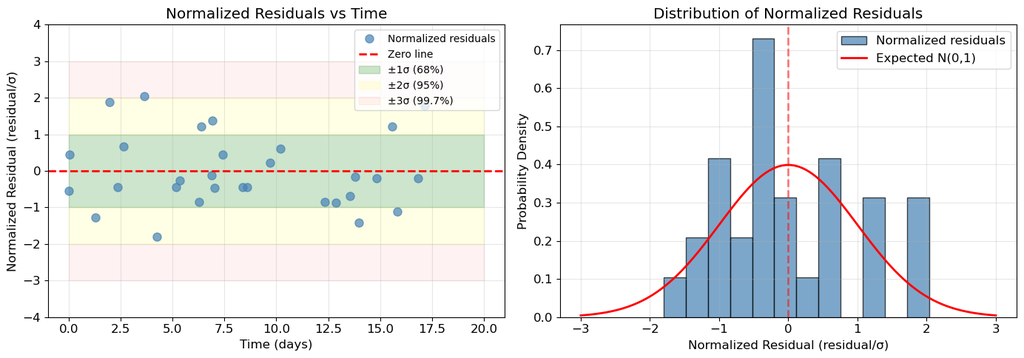

```python
# Create normalized residual plots
fig, (ax1, ax2) = plt.subplots(1, 2, figsize=(14, 5))

# Left plot: Normalized residuals vs time
ax1.plot(observation_times, normalized_residuals, 'o', markersize=8,
         alpha=0.7, color='steelblue', label='Normalized residuals')
ax1.axhline(0, color='red', linestyle='--', linewidth=2, label='Zero line')

# Show ±1σ, ±2σ, ±3σ bands (68%, 95%, 99.7% of data should lie within these)
ax1.fill_between([0, 20], -1, 1, alpha=0.2, color='green', label='±1σ (68%)')
ax1.fill_between([0, 20], -2, -1, alpha=0.1, color='yellow')
ax1.fill_between([0, 20], 1, 2, alpha=0.1, color='yellow', label='±2σ (95%)')
ax1.fill_between([0, 20], -3, -2, alpha=0.05, color='red')
ax1.fill_between([0, 20], 2, 3, alpha=0.05, color='red', label='±3σ (99.7%)')

ax1.set_xlabel('Time (days)')
ax1.set_ylabel('Normalized Residual (residual/σ)')
ax1.set_title('Normalized Residuals vs Time')
ax1.legend(fontsize=10, loc='upper right')
ax1.grid(True, alpha=0.3)
ax1.set_ylim(-4, 4)

# Right plot: Histogram of normalized residuals
ax2.hist(normalized_residuals, bins=12, edgecolor='black', alpha=0.7, color='steelblue',
        density=True, label='Normalized residuals')

# Overlay expected standard normal distribution N(0,1)
x_range = np.linspace(-3, 3, 100)
expected_gaussian = stats.norm.pdf(x_range, loc=0, scale=1)
ax2.plot(x_range, expected_gaussian, 'r-', linewidth=2,
        label='Expected N(0,1)')

ax2.axvline(0, color='red', linestyle='--', linewidth=2, alpha=0.5)
ax2.set_xlabel('Normalized Residual (residual/σ)')
ax2.set_ylabel('Probability Density')
ax2.set_title('Distribution of Normalized Residuals')
ax2.legend(fontsize=12)
ax2.grid(True, alpha=0.3)

plt.tight_layout()
plt.show()
```

**Normalized residual plot interpretation:**

**Left plot**: This shows how observations deviate from the model over time, measured in units of their individual uncertainties. Points should scatter randomly around zero with no systematic patterns or trends. About 68% of points should fall within ±1σ (green band), ~95% within ±2σ (yellow), and ~99.7% within ±3σ (red). Points consistently outside ±2σ suggest outliers or underestimated errors. Systematic patterns (e.g., all early points positive, late points negative) indicate model inadequacy.

**Right plot**: This histogram compares the distribution of normalized residuals to the expected standard normal. If the model and errors are correct, the histogram should match the red curve (standard normal). Good agreement confirms both that our orbital model is appropriate and that our error estimates are realistic.

The left plot shows normalized residuals scattered randomly around zero with no systematic trends. Most points lie within ±1σ (green), a few extend to ±2σ (yellow), and none exceed ±3σ - exactly what we expect for well-estimated errors. The right plot shows the distribution follows the expected Gaussian curve closely, confirming that measurement errors dominate rather than model inadequacy.

If we saw patterns in the residuals - like all residuals at early times being positive and late times being negative, or residuals that grow with time - it would indicate our model is missing something. For example, if the orbit were actually elliptical rather than circular, we'd see systematic residual patterns that a circular model can't capture.

## Local vs Global Minima: A Cautionary Tale

Not all optimization problems are as well-behaved as the examples we've seen. Some problems have multiple **local minima** - valleys in the optimization landscape that aren't the deepest. If an optimization algorithm gets stuck in a local minimum, it will report "success" even though it hasn't found the global (best) solution.

Consider a simple example: the function $f(x) = 2\sin(1.5x) + 0.05x^2 + 0.5\cos(3x)$ has many small valleys (local minima) but only one deepest valley (global minimum). The algorithm gets trapped in whichever valley is nearest to the starting point - if you start optimization at $x = 5$, you might find a local minimum that isn't the best solution, but if you start at $x = 0$, you're more likely to find the global minimum.

Let's visualize what this optimization landscape looks like. The plot below shows a cost function (which could represent $\chi^2$ for different parameter values) with several valleys. To identify the local minima, we'll use the `find_peaks` function we learned in Lecture 17:

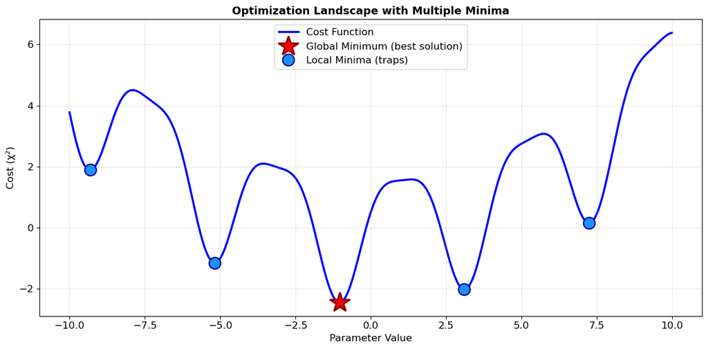

```
Global minimum at x = -1.036, cost = -2.446
Found 4 local minima (traps)
```

```python
from scipy.signal import find_peaks

# Define a function with multiple local minima
def multi_minima_function(x):
    """Function with multiple local minima - oscillating with overall trend"""
    return 2 * np.sin(1.5 * x) + 0.05 * x**2 + 0.5 * np.cos(3 * x)

# Create x values
x = np.linspace(-10, 10, 2000)
y = multi_minima_function(x)

# Find local minima by finding peaks in the negative function
peaks, _ = find_peaks(-y, prominence=0.5)
local_minima_x = x[peaks]
local_minima_y = y[peaks]

# Find the global minimum (the one with lowest y value)
global_min_idx = np.argmin(local_minima_y)
global_min_x = local_minima_x[global_min_idx]
global_min_y = local_minima_y[global_min_idx]

# Remove global minimum from local minima arrays
local_minima_x = np.delete(local_minima_x, global_min_idx)
local_minima_y = np.delete(local_minima_y, global_min_idx)

# Create the plot
plt.figure(figsize=(12, 6))

# Plot the function
plt.plot(x, y, 'b-', linewidth=2.5, label='Cost Function', zorder=1)

# Mark the global minimum
plt.plot(global_min_x, global_min_y, 'r*', markersize=25,
         markeredgecolor='darkred', markeredgewidth=2,
         label=f'Global Minimum (best solution)', zorder=5)

# Mark local minima
plt.plot(local_minima_x, local_minima_y, 'o', color='dodgerblue',
         markersize=14, markeredgecolor='darkblue', markeredgewidth=1.5,
         label='Local Minima (traps)', zorder=4)

plt.xlabel('Parameter Value', fontsize=12)
plt.ylabel('Cost (χ²)', fontsize=12)
plt.title('Optimization Landscape with Multiple Minima', fontsize=13, fontweight='bold')
plt.legend(loc='upper center', fontsize=12)
plt.grid(True, alpha=0.3)
plt.tight_layout()
plt.show()

print(f"Global minimum at x = {global_min_x:.3f}, cost = {global_min_y:.3f}")
print(f"Found {len(local_minima_x)} local minima (traps)")
```

This visualization shows why optimization can be tricky. The red star marks the **global minimum** - the absolute best solution with the lowest cost. The blue circles mark **local minima** - valleys that look like good solutions if you're nearby, but aren't actually the best. An algorithm starting near a blue circle will get trapped there and report "success" even though it hasn't found the red star (global minimum).

The key insight: if you start optimization at different points along the x-axis, you'll end up in different valleys.This is why good initial guesses are crucial. For difficult problems with multiple minima, a robust strategy is **multiple random starts**: run optimization from many different initial guesses and pick the best result (lowest $\chi^2$).

#### Why Pick the Lowest $\chi^2$?

When you have multiple optimization results, how do you know which one is "best"? The answer is simple: **compare their $\chi^2$ values**. Remember that $\chi^2 = \sum_i \left(\frac{\text{residual}_i}{\sigma_i}\right)^2$ quantifies the total disagreement between your model and the data, weighted by measurement uncertainties. A lower $\chi^2$ means better agreement - your model predictions are closer to the observations.

Here's the key insight: if optimization gets stuck in a local minimum, it will produce a **higher** $\chi^2$ than the global minimum. The global minimum is, by definition, the parameter combination that gives the lowest possible $\chi^2$. So by running optimization multiple times from different starting points and picking the result with the lowest $\chi^2$, you're guaranteed to find the best fit—even if some attempts get trapped in sub-optimal local minima.

For example, if you run optimization 20 times and get results with $\chi^2$ values like: 38.2, 38.3, 38.1, 152.7, 38.2, ... you would pick the fit with $\chi^2 = 38.1$ (the lowest). The outlier at 152.7 indicates that particular starting point led to a bad local minimum. The cluster around 38 indicates multiple attempts successfully found the global minimum.

Let's demonstrate this with our binary star radial velocity example. We'll try 20 different random initial guesses and see which one gives the lowest $\chi^2$. Although this particular problem is well-behaved (most starting points will converge to the same good solution), the code shows the general technique that's essential for harder problems with complex optimization landscapes:

```python
# Multiple Random Starts Strategy
# Try many different initial guesses and pick the best result

n_tries = 20  # Number of random starting points to try
results = []

for i in range(n_tries):
    # Generate random initial guesses within reasonable ranges
    # Based on our earlier rough estimates but with randomization
    random_K = np.random.uniform(20, 70)  # Semi-amplitude in km/s
    random_P = np.random.uniform(3, 10)  # Period in days
    random_t0 = np.random.uniform(0, 5)  # Reference time in days
    random_vsys = np.random.uniform(-30, 10)  # Systemic velocity in km/s

    p0_random = [random_K, random_P, random_t0, random_vsys]

    try:
        # Try fitting with this random initial guess
        popt, pcov = curve_fit(
            radial_velocity_model,
            observation_times,
            observed_velocities,
            p0=p0_random,
            sigma=velocity_errors,
            absolute_sigma=True
        )

        # Calculate chi-squared for this fit
        fitted_velocities_try = radial_velocity_model(observation_times, *popt)
        residuals = observed_velocities - fitted_velocities_try
        chi_sq = np.sum((residuals / velocity_errors)**2)

        results.append({
            'chi_squared': chi_sq,
            'fitted_params': popt,
            'success': True
        })

    except Exception as e:
        results.append({'success': False})

# Find the best result (lowest chi-squared)
successful_results = [r for r in results if r.get('success', False)]

if len(successful_results) > 0:
    best_result = min(successful_results, key=lambda x: x['chi_squared'])

    # Extract chi-squared values for analysis
    chi_sq_values = [r['chi_squared'] for r in successful_results]

    print(f"{len(successful_results)} fits succeeded")
    print(f"Best χ² = {best_result['chi_squared']:.2f}")
    print(f"  K = {best_result['fitted_params'][0]:.2f} km/s, P = {best_result['fitted_params'][1]:.3f} days")
    print(f"χ² range: [{min(chi_sq_values):.2f}, {max(chi_sq_values):.2f}]")
else:
    print(f"No fits succeeded out of {n_tries} attempts.")
```

```
20 fits succeeded
Best χ² = 29.31
  K = 45.03 km/s, P = 5.698 days
χ² range: [29.31, 30323.86]
```

**However**, this technique becomes essential for complex problems with multiple local minima. For example:

- Fitting eclipsing binary light curves with multiple possible periods (algorithm might lock onto harmonics)
- Fitting radial velocities for hierarchical triple star systems (multiple periods can interfere)
- Fitting multi-period variable stars where the algorithm might lock onto beat frequencies
- Non-linear models with degeneracies where different parameter combinations give similar $\chi^2$

In those cases, you might see results like: $\chi^2 = [38.1, 38.3, 152.8, 38.2, 97.6, 38.1, ...]$ where some attempts get stuck in bad local minima (high $\chi^2$) while others find the global minimum (low $\chi^2$ around 38). By trying multiple random starts and picking the lowest $\chi^2$, you're guaranteed to find the best fit even when the optimization landscape is treacherous. For the binary star problem, the correct period is obvious from visual inspection, but for more complex systems (like triple stars or eccentric orbits), this technique can be the difference between finding the correct solution and reporting incorrect orbital parameters.

## Optimization Methods and Algorithms

Now that we understand the challenges of optimization (like local minima), let's look at the different algorithms available. Throughout this lecture, we've been using `curve_fit` to find optimal parameters. Understanding what's happening under the hood helps you choose the right tool and diagnose problems when fits fail.

All optimization algorithms share a common strategy: start from an initial guess, evaluate the objective function, decide where to search next, take a step in a promising direction, and repeat until convergence. The algorithms differ in how they decide where to step next.

**Gradient-based methods** (when derivatives are available):

- **Levenberg-Marquardt**: Specifically designed for least-squares curve fitting. This is what `curve_fit` uses by default - it's fast and reliable for our astronomy problems.
- **BFGS and Conjugate Gradient**: General-purpose methods that use gradient information for efficient convergence.
- **Newton's Method**: Uses second derivatives for very fast convergence near the minimum.

**Gradient-free methods** (when gradients aren't available or functions aren't smooth):

- **Nelder-Mead**: Maintains a simplex shape and moves it toward the minimum. Robust but slower.
- **Powell's Method**: Uses conjugate directions without computing gradients.
- **Differential Evolution**: A global optimization method that can escape local minima by exploring the parameter space more broadly.

For curve fitting to astronomical data, `curve_fit` with its Levenberg-Marquardt algorithm is generally the best choice. It's specifically optimized for least-squares problems and handles the weighted fitting (via `sigma` parameter) that we need for measurement uncertainties. The general `minimize` function from `scipy.optimize` gives access to other methods if you need them for special cases - for example, Differential Evolution can be useful for problems with many local minima where the multiple random starts strategy might be insufficient.

## Summary

### Key Concepts

In this lecture, you've learned:

- **The Connection Between Statistics and Optimization**: Understanding that calculating a mean or weighted average is actually solving an optimization problem - finding values that minimize chi-squared. This insight from Lecture 17 generalizes to arbitrary models with multiple parameters, where minimizing chi-squared means finding parameters that make your model best match observations while properly accounting for measurement uncertainties
- **Cost Functions and Optimization Landscapes**: Using cost functions to quantify disagreement between model and data, with lower values meaning better fits. Visualizing optimization as navigating a landscape where valleys represent good solutions. Understanding that convex problems with a single valley are straightforward, while landscapes with multiple valleys require careful strategies to avoid getting trapped in local minima
- **The scipy.optimize Module**: Using `minimize_scalar` for one-parameter problems with algorithms like Brent's method that efficiently find minima. Using `curve_fit` for multi-parameter curve fitting with the Levenberg-Marquardt algorithm specifically optimized for least-squares problems. Using `fsolve` for solving nonlinear equations (root-finding) such as deriving companion masses from mass functions. Using the general `minimize` function with various algorithms (gradient-based like BFGS for smooth problems, gradient-free like Nelder-Mead for rougher landscapes) for diverse optimization challenges
- **Linear and Non-Linear Fitting**: Recognizing that linear models like stellar proper motion have guaranteed convergence to the global minimum using linear algebra. Understanding that non-linear models like sinusoidal variations or orbital curves require good initial parameter guesses based on physical intuition to help algorithms converge correctly. Learning to provide sigma parameters to properly implement weighted least squares with measurement uncertainties
- **Parameter Uncertainties from Covariance Matrices**: Extracting parameter uncertainties from the covariance matrix returned by curve_fit using `np.sqrt(np.diag(pcov))`. Understanding that the covariance matrix describes both individual parameter uncertainties and correlations between parameters. Recognizing that the full theory of covariance matrices and maximum likelihood estimation will be covered in second and third-year statistics courses
- **Evaluating Fit Quality Through Residual Analysis**: Checking that residuals scatter randomly around zero with no systematic patterns. Verifying their distribution matches measurement uncertainties. Using chi-squared to quantify overall fit quality, with reduced chi-squared near unity indicating appropriate model and error estimates. Recognizing that systematic residual patterns indicate model inadequacy, while reduced chi-squared far from unity suggests mis-estimated uncertainties or wrong functional form

### What You Can Now Do

After working through this material, you should be able to:

- Use `curve_fit` to extract best-fit parameters and uncertainties from noisy measurements with physical models
- Use `fsolve` to solve nonlinear equations such as deriving physical quantities from observational constraints
- Provide appropriate initial guesses for non-linear problems to help optimization converge reliably
- Properly weight observations by measurement uncertainties using the sigma parameter in curve_fit
- Extract parameter uncertainties from covariance matrices and interpret them as confidence intervals
- Evaluate fit quality through visual inspection, residual plots, chi-squared statistics, and residual distributions
- Choose between `minimize_scalar`, `curve_fit`, `fsolve`, and `minimize` based on your problem type
- Use bounded optimization for parameters with physical constraints
- Recognize local minimum problems and apply strategies to address them

### Practice Suggestions

To solidify and extend these skills, work through these practice problems:

1. Create a light curve with two superposed sinusoidal periods (simulating a pulsating star in a binary system), define a model with six parameters, and fit to recover both periods
2. Model a transiting exoplanet with periodic box-shaped dips, fit synthetic noisy data to recover planet properties
3. Simulate a binary where you observe radial velocities for both stars simultaneously, fit both curves with appropriate constraints
4. Extend the binary star example to elliptical orbits with additional parameters for eccentricity and argument of periastron
5. Download actual variable star photometry from the AAVSO database or binary star radial velocities from the literature, fit appropriate models and compare your results to published values
6. Create visualization tools showing how different optimization algorithms navigate parameter space for two-parameter models
7. Investigate how fit quality and parameter uncertainties depend on data quality by varying numbers of observations and noise levels

### Looking Ahead

You now have the statistical foundation (Lecture 17) and optimization skills (Lecture 18) needed for computational astronomy. In the next lecture, you'll immediately apply these curve fitting techniques to time series analysis, working with simulated light curves similar to those from the Kepler mission to detect and characterize transiting exoplanets. Beyond that, you'll work with astronomical images and arrays, handle multi-dimensional data, apply numerical methods to astrophysical problems, and build complete data analysis pipelines. The curve fitting and optimization skills you've learned are fundamental to almost all astronomical research—every measurement reported in scientific papers, from exoplanet properties to stellar parameters to cosmological constraints, relies on fitting models to data and quantifying uncertainties. You now possess the core computational tools to transform astronomical observations into physical understanding, turning light into knowledge about stars, galaxies, and the cosmos.